# RQ1: What drives the real cost per m² of new houses across districts?

Building consents (Stats NZ, Aug 2026) — linear regression, ridge and lasso, tree-based models

Andrew Boulton — while True: learn(), Group 8, STAT462

This document answers research question 1 of our project: *what drives the real cost per square metre of new houses across New Zealand’s districts?* It starts from the model-ready table built by Niwesh (`rq1_model_data.csv`, Step 1 of his pipeline), builds the modelling table we use for every model, looks at the data before fitting anything, and then fits the models in the order the course teaches them: simple and multiple linear regression (Modules 1–2), ridge and lasso (ISLR2 §6.5), a regression tree, a random forest and a boosted model (Module 6). Every model is judged on the same time-ordered test set (2020Q1–2026Q2) by test MSE and $R^2$, and the document ends with a comparison against the numbers in Niwesh’s own notebooks, so the group has two independent builds of the same question.

# 1 Set up

## 1.1 Data

The table has one row per district and quarter. Niwesh’s Step 1 notebook (`01_rq1_data_preparation.Rmd`, branch `niwesh`) builds it from the Stats NZ *Building consents by territorial authority (Monthly)* file: months are summed to quarters, the consented value of new houses is divided by their floor area to give nominal $/m², GST of the day is removed, the value is deflated to June-2026 dollars with the CGPI dwelling-units index (`CEPQ.S611011A`) and 15% GST is put back. Rows with fewer than five new houses in the quarter were dropped before the file was written, so every row we read is a usable one.

```r
rq1_raw <- read_csv(file.path(data_root, "rq1_model_data.csv"),
                    show_col_types = FALSE) %>%
  mutate(across(c(ta, region, island, split), as.factor),
         quarter = factor(quarter, levels = 1:4),
         is_city = as.logical(is_city),
         in_model = as.logical(in_model))

cat("Rows:", nrow(rq1_raw), " Columns:", ncol(rq1_raw),
    " Districts:", n_distinct(rq1_raw$ta),
    " Quarters:", min(rq1_raw$yq), "to", max(rq1_raw$yq), "\n")
```

```
## Rows: 8662  Columns: 43  Districts: 67  Quarters: 1990Q2 to 2026Q2
```

```r
glimpse(rq1_raw)
```

```
## Rows: 8,662
## Columns: 43
## $ ta                 <fct> Ashburton District, Ashburton District, Ashburton D…
## $ region             <fct> Canterbury Region, Canterbury Region, Canterbury Re…
## $ island             <fct> South, South, South, South, South, South, South, So…
## $ is_city            <lgl> FALSE, FALSE, FALSE, FALSE, FALSE, FALSE, FALSE, FA…
## $ year               <dbl> 1990, 1990, 1990, 1991, 1991, 1991, 1991, 1992, 199…
## $ quarter            <fct> 2, 3, 4, 1, 2, 3, 4, 1, 2, 3, 4, 1, 2, 3, 4, 1, 2, …
## $ yq                 <chr> "1990Q2", "1990Q3", "1990Q4", "1991Q1", "1991Q2", "…
## $ t_index            <dbl> 2, 3, 4, 5, 6, 7, 8, 9, 10, 11, 12, 13, 14, 15, 16,…
## $ split              <fct> train, train, train, train, train, train, train, tr…
## $ in_model           <lgl> TRUE, TRUE, TRUE, TRUE, TRUE, TRUE, TRUE, TRUE, TRU…
## $ real_cost_m2       <dbl> 2551.470, 2540.621, 2427.964, 2837.994, 2501.116, 2…
## $ log_real_cost_m2   <dbl> 7.844425, 7.840164, 7.794809, 7.950853, 7.824492, 7…
## $ rel_log_cost_m2    <dbl> -0.097086471, -0.089658616, -0.131637137, 0.0207337…
```

[output cut: 30 more lines]

8,662 district-quarters, 67 districts, 1990Q2 to 2026Q2, 43 columns. The data dictionary that travels with the file:

```r
read_csv(file.path(data_root, "rq1_data_dictionary.csv"),
         show_col_types = FALSE) %>%
  knitr::kable(caption = "Data dictionary for rq1_model_data.csv (Niwesh, Step 1)")
```

Data dictionary for rq1_model_data.csv (Niwesh, Step 1)

[output not shown]

## 1.2 The modelling table

Not every column is a legitimate predictor. We keep two responses, the drivers, and the two geography columns, and drop the rest. The rule for what is a driver: it must be known in the same quarter from *counts* (how many of what was consented) or from the past, never from the dollar value of the houses themselves — otherwise the model is told the answer.

```r
# the two responses: relative cost (headline) and real $/m2 (secondary, section 6)
responses <- c("rel_log_cost_m2", "log_real_cost_m2")

# the drivers: same-quarter counts and shares, population pressure, and the time index
drivers <- c("t_index",             # quarter number, 1990Q1 = 1
             "avg_house_m2",        # average floor area of a new house
             "rel_house_m2",        # house size relative to the rest of NZ, same quarter
             "log_houses_n",        # log number of new houses
             "multiunit_share",     # share of new dwellings that are not stand-alone houses
             "apt_share",           # share that are apartments
             "retire_share",        # share that are retirement-village units
             "dwell_per_1000",      # new dwellings per 1,000 residents, year to quarter end
             "houses_yoy",          # log growth in houses vs the same quarter last year
             "log_resid_alt_real",  # log real $ of residential alterations
             "log_nonres_real")     # log real $ of new non-residential work

df <- rq1_raw %>%
  dplyr::select(ta, region, year, quarter, yq, split, houses_n,
                all_of(responses), all_of(drivers))

dim(df)
```

```
## [1] 8662   20
```

**What was left out, and why.** `nominal_cost_m2`, `houses_val`, `real_cost_m2`, `loo_cost_m2` and `real_factor` are the response or its ingredients (leakage). `real_cost_m2_lag1` / `_lag4` are the response one and four quarters earlier — a persistence benchmark, not a driver of cost, so they are kept out of the explanatory models. `houses_m2`, `dwell_n`, `apt_n`, `retire_n`, `town_n`, `resid_new_val`, `resid_alt_val`, `nonres_new_val` are the raw counts and dollars that the shares and logs above are built from, and would duplicate them. `island`, `is_city` and `quarter` (season) explained under 0.5% of the variance in Niwesh’s EDA and are dropped as features; `quarter` and `year` stay in the table for grouping only.

**Rows: our frame vs Niwesh’s.** Niwesh fits his models on 1996Q1 onward and drops Chatham Islands and Kawerau (5,694 train / 1,608 test, 65 districts). We keep the full 1990Q2+ frame and all 67 districts as agreed on 6 Nov (7,051 / 1,611). The practical difference is small — Chatham Islands has 2 rows and Kawerau 3 — but two drivers are not available before 1996: `dwell_per_1000` (the per-1,000-residents series starts in 1996) is `NA` for all 1,355 pre-1996 rows, and `houses_yoy` is `NA` for the first year of each district (238 rows). Any model that uses them is therefore fitted on the rows where they exist; the table below shows how many that is. Where we compare against Niwesh’s numbers in section 6 we say which frame each number comes from.

```r
# how many rows survive once the drivers that start in 1996 are required
df_complete <- df %>% drop_na(all_of(drivers))

bind_rows(
  df          %>% count(split, name = "all rows"),
  df_complete %>% count(split, name = "rows with every driver")
) %>%
  group_by(split) %>%
  summarise(across(everything(), ~ sum(.x, na.rm = TRUE))) %>%
  knitr::kable(caption = "Rows available per split")
```

Rows available per split

| split | all rows | rows with every driver |
| --- | --- | --- |
| test | 1611 | 1611 |
| train | 7051 | 5696 |

## 1.3 Train and test sets

The split is by time, not at random: the labs’ `sample()` split would let 2024 rows teach the model about 2023, which is not the question a forecaster faces. Niwesh’s file carries the split already (`split == "train"` up to 2019Q4, `"test"` from 2020Q1), and we use it as given so both builds are judged on exactly the same quarters.

```r
df_train <- df %>% dplyr::filter(split == "train")
df_test  <- df %>% dplyr::filter(split == "test")

cat("Training set size:", nrow(df_train), " (", min(df_train$yq), "to", max(df_train$yq), ")\n")
```

```
## Training set size: 7051  ( 1990Q2 to 2019Q4 )
```

```r
cat("Test set size:    ", nrow(df_test),  " (", min(df_test$yq),  "to", max(df_test$yq),  ")\n")
```

```
## Test set size:     1611  ( 2020Q1 to 2026Q2 )
```

```r
cat("Districts in train:", n_distinct(df_train$ta), " in test:", n_distinct(df_test$ta), "\n")
```

```
## Districts in train: 67  in test: 67
```

7,051 training and 1,611 test rows, all 67 districts in both. The test years include COVID and the 2021–23 cost spike, so this is a hard test on purpose.

# 2 First impression

Before fitting anything: what does the response look like, which districts sit where, and how do the drivers relate to it and to each other.

## 2.1 The two responses

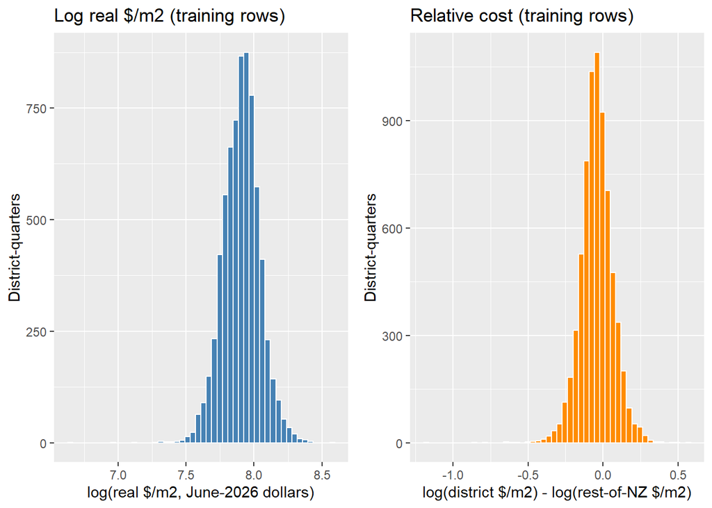

```r
p1 <- ggplot(df_train, aes(x = log_real_cost_m2)) +
  geom_histogram(bins = 50, fill = "steelblue", colour = "white") +
  labs(title = "Log real $/m2 (training rows)",
       x = "log(real $/m2, June-2026 dollars)", y = "District-quarters")

p2 <- ggplot(df_train, aes(x = rel_log_cost_m2)) +
  geom_histogram(bins = 50, fill = "darkorange", colour = "white") +
  labs(title = "Relative cost (training rows)",
       x = "log(district $/m2) - log(rest-of-NZ $/m2)", y = "District-quarters")

grid.arrange(p1, p2, ncol = 2)
```

Both are close to symmetric on the log scale, which is what the log was for. The relative response is centred just below zero (the median district is slightly cheaper than the country as a whole, because the national figure is pulled up by Auckland) and most rows sit within ±0.3, i.e. within about 30% of the rest of the country.

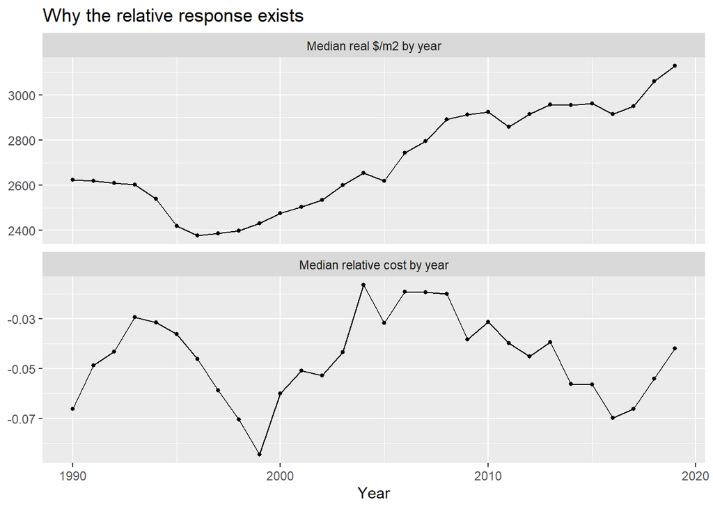

```r
df_train %>%
  group_by(year) %>%
  summarise(real = median(exp(log_real_cost_m2)),
            relative = median(rel_log_cost_m2)) %>%
  pivot_longer(-year, names_to = "response", values_to = "median") %>%
  ggplot(aes(x = year, y = median)) +
  geom_line() + geom_point(size = 1) +
  facet_wrap(~ response, scales = "free_y", ncol = 1,
             labeller = as_labeller(c(real = "Median real $/m2 by year",
                                      relative = "Median relative cost by year"))) +
  labs(title = "Why the relative response exists", x = "Year", y = NULL)
```

## 2.2 Districts

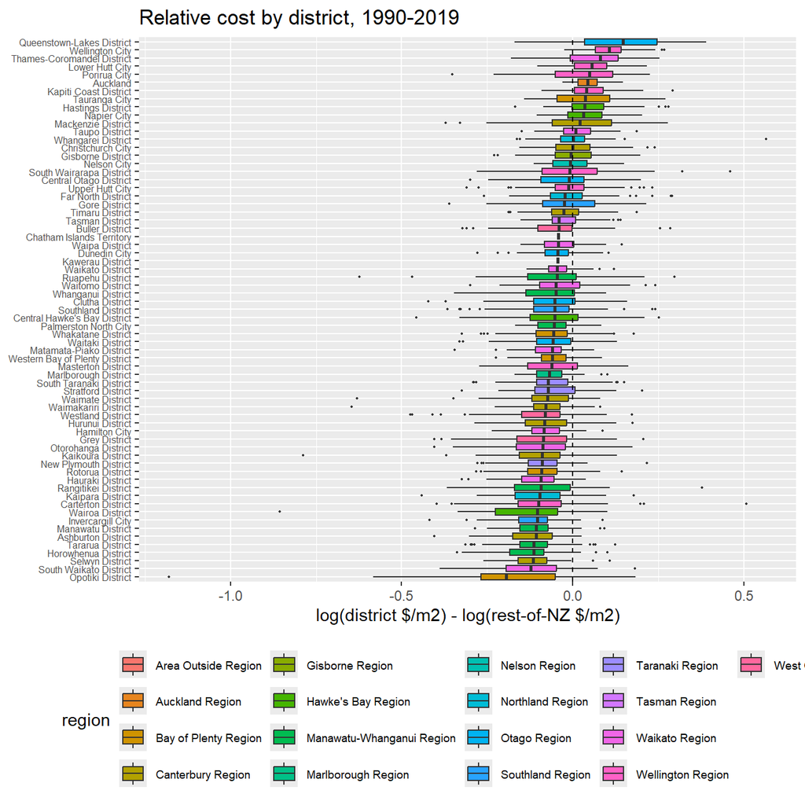

```r
district_order <- df_train %>%
  group_by(ta) %>%
  summarise(med = median(rel_log_cost_m2)) %>%
  arrange(med) %>% pull(ta)

df_train %>%
  mutate(ta = factor(ta, levels = district_order)) %>%
  ggplot(aes(x = ta, y = rel_log_cost_m2, fill = region)) +
  geom_boxplot(outlier.size = 0.4) +
  coord_flip() +
  geom_hline(yintercept = 0, linetype = "dashed") +
  labs(title = "Relative cost by district, 1990-2019",
       x = NULL, y = "log(district $/m2) - log(rest-of-NZ $/m2)") +
  theme(legend.position = "bottom", legend.text = element_text(size = 7),
        axis.text.y = element_text(size = 6))
```

```r
df_train %>%
  group_by(ta, region) %>%
  summarise(median_ratio = exp(median(rel_log_cost_m2)),
            IQR = IQR(rel_log_cost_m2), rows = n(), .groups = "drop") %>%
  arrange(desc(median_ratio)) %>%
  slice(c(1:6, (n() - 5):n())) %>%
  mutate(across(c(median_ratio, IQR), ~ round(.x, 2))) %>%
  knitr::kable(caption = "Six dearest and six cheapest districts (median ratio to the rest of NZ, training years)")
```

Six dearest and six cheapest districts (median ratio to the rest of NZ, training years)

| ta | region | median_ratio | IQR | rows |
| --- | --- | --- | --- | --- |
| Queenstown-Lakes District | Otago Region | 1.16 | 0.21 | 119 |
| Wellington City | Wellington Region | 1.11 | 0.08 | 119 |
| Thames-Coromandel District | Waikato Region | 1.08 | 0.14 | 119 |
| Lower Hutt City | Wellington Region | 1.06 | 0.09 | 119 |
| Porirua City | Wellington Region | 1.05 | 0.17 | 119 |
| Auckland | Auckland Region | 1.05 | 0.06 | 119 |
| Ashburton District | Canterbury Region | 0.90 | 0.12 | 119 |
| Tararua District | Manawatu-Whanganui Region | 0.89 | 0.08 | 74 |
| Horowhenua District | Manawatu-Whanganui Region | 0.89 | 0.10 | 119 |
| Selwyn District | Canterbury Region | 0.89 | 0.08 | 119 |
| South Waikato District | Waikato Region | 0.89 | 0.15 | 88 |
| Opotiki District | Bay of Plenty Region | 0.82 | 0.22 | 83 |

The ordering is stable enough to matter: the same districts stay at the top and bottom for thirty years. That is the first clue that *where* explains a lot, and it is why a district fixed effect is the ceiling we compare the drivers against in section 3.

## 2.3 How much is location, how much is time?

Three one-way fits with nothing but group means — the same idea as the labs’ “predict the average” baseline, applied to each grouping in turn.

$$R^2 = 1 - \frac{RSS}{TSS}, \qquad RSS =
\Sigma_{i=1}^{n}(y_i - \bar y_{g(i)})^2$$

```r
r2_group <- function(y, g) {
  tss <- sum((y - mean(y))^2)
  rss <- sum((y - ave(y, g, FUN = mean))^2)
  1 - rss / tss
}

tibble(grouping = c("District", "Region", "Year", "Quarter (season)", "District + year"),
       `relative cost` = c(r2_group(df_train$rel_log_cost_m2, df_train$ta),
                           r2_group(df_train$rel_log_cost_m2, df_train$region),
                           r2_group(df_train$rel_log_cost_m2, df_train$year),
                           r2_group(df_train$rel_log_cost_m2, df_train$quarter),
                           r2_group(df_train$rel_log_cost_m2, interaction(df_train$ta, df_train$year))),
       `log real $/m2` = c(r2_group(df_train$log_real_cost_m2, df_train$ta),
                           r2_group(df_train$log_real_cost_m2, df_train$region),
                           r2_group(df_train$log_real_cost_m2, df_train$year),
                           r2_group(df_train$log_real_cost_m2, df_train$quarter),
                           r2_group(df_train$log_real_cost_m2, interaction(df_train$ta, df_train$year)))) %>%
  mutate(across(-grouping, ~ round(.x, 3))) %>%
  knitr::kable(caption = "Share of training variance explained by group means alone")
```

Share of training variance explained by group means alone

| grouping | relative cost | log real $/m2 |
| --- | --- | --- |
| District | 0.318 | 0.193 |
| Region | 0.105 | 0.062 |
| Year | 0.025 | 0.405 |
| Quarter (season) | 0.000 | 0.000 |
| District + year | 0.686 | 0.804 |

On the relative response the district alone explains about a third of the variance and the year almost none — time has been taken out. On the real response it is the other way round: the year explains about 40% and the district under 20%. Season explains nothing on either, which is why `quarter` is not a feature. Whatever the drivers achieve in the next sections has to be read against the district-only number: a model of measured drivers that reaches it has explained *why* the dear districts are dear.

## 2.4 The drivers

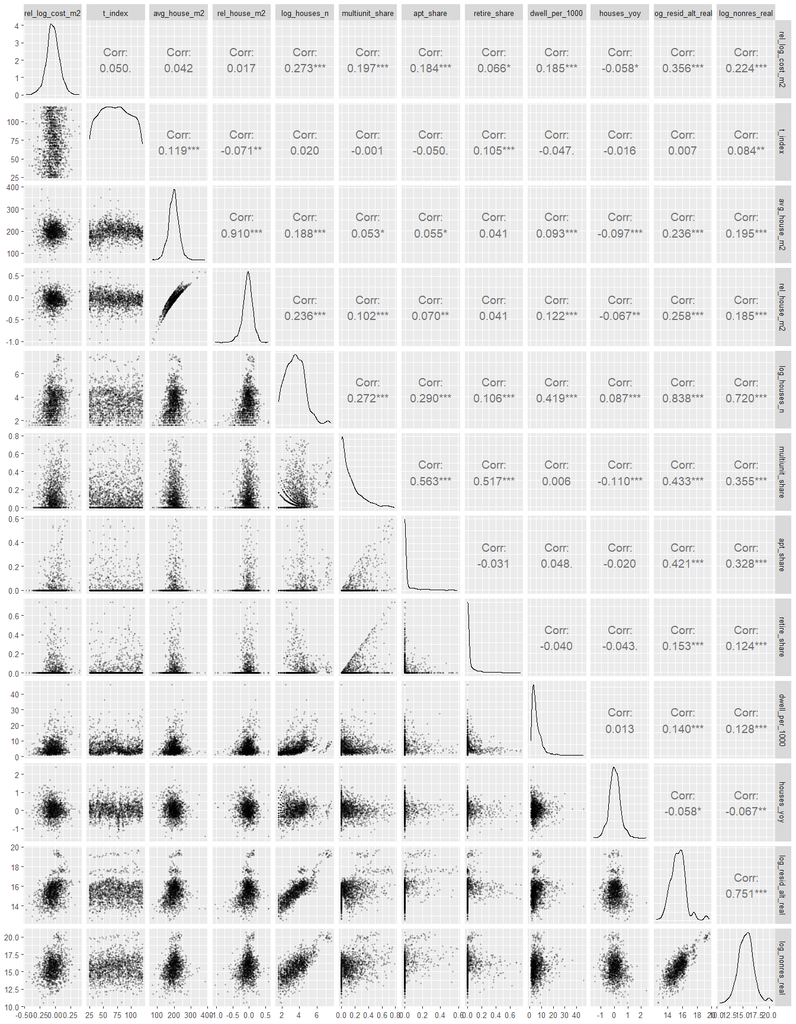

```r
set.seed(462)
df_train %>%
  drop_na(all_of(drivers)) %>%
  slice_sample(n = 1500) %>%
  dplyr::select(rel_log_cost_m2, all_of(drivers)) %>%
  ggpairs(lower = list(continuous = wrap("points", alpha = 0.2, size = 0.4)),
          upper = list(continuous = wrap("cor", size = 2.5)),
          progress = FALSE) +
  theme_grey(base_size = 6)
```

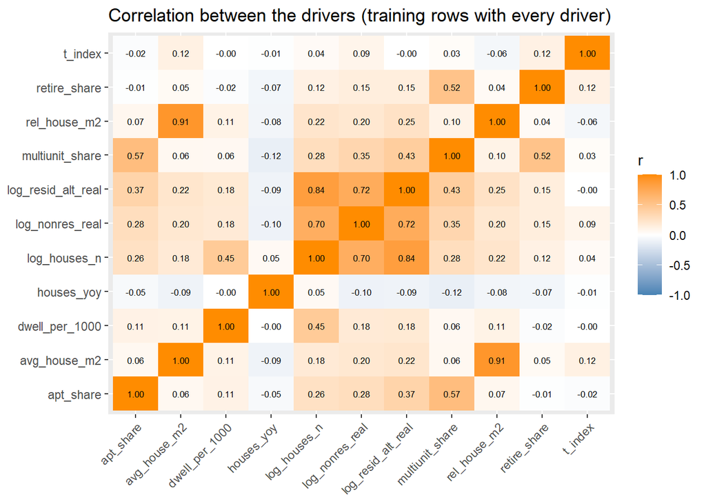

```r
cor_long <- df_train %>%
  drop_na(all_of(drivers)) %>%
  dplyr::select(all_of(drivers)) %>%
  cor() %>%
  as.data.frame() %>%
  rownames_to_column("x") %>%
  pivot_longer(-x, names_to = "y", values_to = "r")

ggplot(cor_long, aes(x = x, y = y, fill = r)) +
  geom_tile() +
  geom_text(aes(label = sprintf("%.2f", r)), size = 2.2) +
  scale_fill_gradient2(low = "steelblue", mid = "white", high = "darkorange", limits = c(-1, 1)) +
  labs(title = "Correlation between the drivers (training rows with every driver)", x = NULL, y = NULL) +
  theme(axis.text.x = element_text(angle = 45, hjust = 1))
```

```r
# the pairs that will matter for ridge vs lasso
cor_long %>%
  dplyr::filter(x < y, abs(r) > 0.6) %>%
  arrange(desc(abs(r))) %>%
  mutate(r = round(r, 2)) %>%
  knitr::kable(caption = "Driver pairs with |r| > 0.6")
```

Driver pairs with |r| > 0.6

| x | y | r |
| --- | --- | --- |
| avg_house_m2 | rel_house_m2 | 0.91 |
| log_houses_n | log_resid_alt_real | 0.84 |
| log_nonres_real | log_resid_alt_real | 0.72 |
| log_houses_n | log_nonres_real | 0.70 |

Two pairs are strongly related: `avg_house_m2` with `rel_house_m2` ($r \approx 0.9$; the second is the first measured against the rest of the country, so they move together within a quarter) and `log_houses_n` with `log_resid_alt_real` ($r \approx 0.8$; big districts build more and renovate more). `log_nonres_real` sits at about 0.7 with both of the size measures for the same reason. Ordinary least squares will split the credit between the members of each pair arbitrarily and give wide standard errors; this is exactly the situation ridge and lasso are for, and section 4 shows them handling it differently.

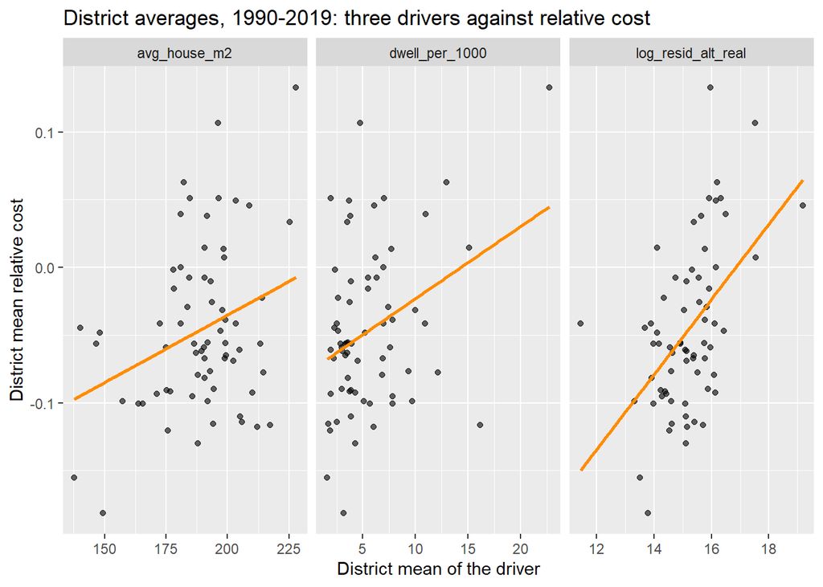

```r
df_train %>%
  group_by(ta) %>%
  summarise(across(c(rel_log_cost_m2, log_resid_alt_real, dwell_per_1000, avg_house_m2),
                   ~ mean(.x, na.rm = TRUE))) %>%
  pivot_longer(-c(ta, rel_log_cost_m2), names_to = "driver", values_to = "value") %>%
  ggplot(aes(x = value, y = rel_log_cost_m2)) +
  geom_point(alpha = 0.6) +
  geom_smooth(method = "lm", se = FALSE, colour = "darkorange") +
  facet_wrap(~ driver, scales = "free_x") +
  labs(title = "District averages, 1990-2019: three drivers against relative cost",
       x = "District mean of the driver", y = "District mean relative cost")
```

At the district level the picture is already readable: districts with more alteration spending and bigger houses are dearer per m²; the population pressure measure is positive but noisier. These are between-district relationships. The models in the next sections are fitted on district-quarters, so they also see how a district’s cost moves when its own alterations or growth change from one quarter to the next.

*Which model does best with these drivers — and does any of them reach the district-only ceiling?*

# 3 Linear regression

## 3.1 The rows every model is fitted on

Two drivers do not exist for the early years: `dwell_per_1000` starts in 1996 and `houses_yoy` needs the same quarter a year earlier. `lm()` would drop the affected rows silently and `glmnet()` refuses missing values altogether, so we do it once, in the open, and every model from here on is fitted and tested on the same rows.

```r
df_train_c <- df_train %>% drop_na(all_of(drivers))
df_test_c  <- df_test  %>% drop_na(all_of(drivers))

cat("Training rows with every driver:", nrow(df_train_c),
    " (", min(df_train_c$yq), "to", max(df_train_c$yq), ")\n")
```

```
## Training rows with every driver: 5696  ( 1996Q1 to 2019Q4 )
```

```r
cat("Test rows with every driver:    ", nrow(df_test_c),
    " (", min(df_test_c$yq),  "to", max(df_test_c$yq),  ")\n")
```

```
## Test rows with every driver:     1611  ( 2020Q1 to 2026Q2 )
```

```r
# the drivers-only frames the models see (no identifiers, one response)
train_drv <- df_train_c %>% dplyr::select(rel_log_cost_m2, all_of(drivers))
test_drv  <- df_test_c  %>% dplyr::select(rel_log_cost_m2, all_of(drivers))
```

Two helpers used throughout: the test-set metrics the labs compute by hand, wrapped so every model reports them the same way, and a running results table.

$$MSE = \frac{1}{n}\Sigma_{i=1}^{n}(y_i -
\hat y_i)^2, \qquad
R^2_{test} = 1 - \frac{\Sigma(y_i - \hat y_i)^2}{\Sigma(y_i - \bar
y_{train})^2}$$

```r
y_train_mean <- mean(train_drv$rel_log_cost_m2)

test_metrics <- function(pred, actual) {
  mse <- mean((actual - pred)^2)
  c(test_MSE  = mse,
    test_RMSE = sqrt(mse),
    test_R2   = 1 - sum((actual - pred)^2) / sum((actual - y_train_mean)^2))
}

results <- tibble(model = character(), set = character(),
                  train_R2 = numeric(), adj_R2 = numeric(),
                  test_MSE = numeric(), test_RMSE = numeric(), test_R2 = numeric())

add_result <- function(results, model, set, fit_R2 = NA, fit_adjR2 = NA, metrics) {
  results %>% add_row(model = model, set = set,
                      train_R2 = fit_R2, adj_R2 = fit_adjR2,
                      test_MSE = metrics[["test_MSE"]],
                      test_RMSE = metrics[["test_RMSE"]],
                      test_R2 = metrics[["test_R2"]])
}
```

## 3.2 Simple linear regression, by hand and by `lm()`

The single strongest driver at district level was residential alteration spending (section 2). One predictor, the Module 1 formulas, then `lm()` to confirm them.

$$b_1 = \frac{\Sigma_{i=1}^{n}(x_i - \bar
x)(y_i - \bar y)}{\Sigma_{i=1}^{n}(x_i - \bar x)^2},
\qquad b_0 = \bar y - b_1 \bar x$$

```r
x <- train_drv$log_resid_alt_real
y <- train_drv$rel_log_cost_m2

# slope and intercept from the formulas
b1 <- sum((x - mean(x)) * (y - mean(y))) / sum((x - mean(x))^2)
b0 <- mean(y) - b1 * mean(x)

# the same model with lm()
slr.fit <- lm(rel_log_cost_m2 ~ log_resid_alt_real, data = train_drv)

cat(sprintf("By hand: b0 = %.4f, b1 = %.4f\n", b0, b1))
```

```
## By hand: b0 = -0.5830, b1 = 0.0351
```

```r
cat(sprintf("lm():    b0 = %.4f, b1 = %.4f\n", coef(slr.fit)[1], coef(slr.fit)[2]))
```

```
## lm():    b0 = -0.5830, b1 = 0.0351
```

```r
summary(slr.fit)
```

```
##
## Call:
## lm(formula = rel_log_cost_m2 ~ log_resid_alt_real, data = train_drv)
##
## Residuals:
##      Min       1Q   Median       3Q      Max
## -0.51233 -0.06351 -0.00477  0.05839  0.58053
##
## Coefficients:
##                     Estimate Std. Error t value Pr(>|t|)
## (Intercept)        -0.583038   0.019389  -30.07   <2e-16 ***
## log_resid_alt_real  0.035144   0.001254   28.02   <2e-16 ***
## ---
## Signif. codes:  0 '***' 0.001 '**' 0.01 '*' 0.05 '.' 0.1 ' ' 1
##
## Residual standard error: 0.09897 on 5694 degrees of freedom
## Multiple R-squared:  0.1212, Adjusted R-squared:  0.1211
## F-statistic: 785.4 on 1 and 5694 DF,  p-value: < 2.2e-16
```

```r
# confidence interval for b1 from the t distribution, then confint() to check
n     <- nrow(train_drv)
se_b1 <- summary(slr.fit)$coefficients["log_resid_alt_real", "Std. Error"]
t_crit <- qt(1 - 0.05 / 2, df = n - 2)
cat(sprintf("95%% CI for b1 by hand: (%.4f, %.4f)\n", b1 - t_crit * se_b1, b1 + t_crit * se_b1))
```

```
## 95% CI for b1 by hand: (0.0327, 0.0376)
```

```r
confint(slr.fit)
```

```
##                          2.5 %      97.5 %
## (Intercept)        -0.62104824 -0.54502769
## log_resid_alt_real  0.03268598  0.03760266
```

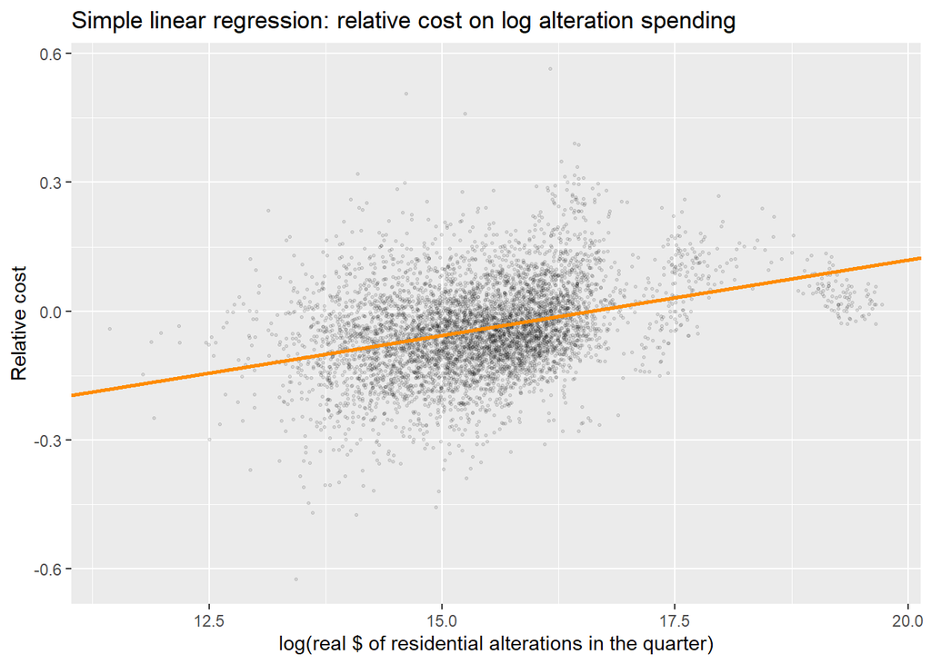

```r
ggplot(train_drv, aes(x = log_resid_alt_real, y = rel_log_cost_m2)) +
  geom_point(alpha = 0.1, size = 0.6) +
  geom_abline(intercept = b0, slope = b1, colour = "darkorange", linewidth = 1) +
  labs(title = "Simple linear regression: relative cost on log alteration spending",
       x = "log(real $ of residential alterations in the quarter)",
       y = "Relative cost")
```

```r
pred_slr <- predict(slr.fit, newdata = test_drv)
m_slr    <- test_metrics(pred_slr, test_drv$rel_log_cost_m2)
results  <- add_result(results, "Simple linear regression", "one driver",
                       summary(slr.fit)$r.squared, summary(slr.fit)$adj.r.squared, m_slr)
paste("The test MSE of the SLR model is", round(m_slr[["test_MSE"]], 5))
```

```
## [1] "The test MSE of the SLR model is 0.01637"
```

The slope is positive and many standard errors from zero: a district that spends more on alterations in a quarter is dearer per m² for new houses in that quarter. On its own, though, one driver explains about 12% of the variation ($R^2 = 0.12$), and the cloud around the line is wide. Alteration spending is a proxy for a busy, wealthy market, not the cost itself.

## 3.3 Multiple linear regression on the drivers

All eleven drivers at once.

```r
mlr.fit <- lm(rel_log_cost_m2 ~ ., data = train_drv)
summary(mlr.fit)
```

```
##
## Call:
## lm(formula = rel_log_cost_m2 ~ ., data = train_drv)
##
## Residuals:
##      Min       1Q   Median       3Q      Max
## -0.50526 -0.05860 -0.00297  0.05598  0.59327
##
## Coefficients:
##                      Estimate Std. Error t value Pr(>|t|)
## (Intercept)        -0.9253608  0.0398240 -23.236  < 2e-16 ***
## t_index             0.0001533  0.0000522   2.937 0.003330 **
## avg_house_m2        0.0004975  0.0001098   4.532 5.97e-06 ***
## rel_house_m2       -0.1362478  0.0218794  -6.227 5.09e-10 ***
## log_houses_n       -0.0268045  0.0027975  -9.582  < 2e-16 ***
## multiunit_share     0.0386373  0.0136617   2.828 0.004698 **
## apt_share           0.0221785  0.0234963   0.944 0.345253
## retire_share        0.0024182  0.0200211   0.121 0.903868
## dwell_per_1000      0.0065109  0.0003471  18.758  < 2e-16 ***
## houses_yoy         -0.0013973  0.0032283  -0.433 0.665148
## log_resid_alt_real  0.0578014  0.0028330  20.403  < 2e-16 ***
## log_nonres_real    -0.0046366  0.0012528  -3.701 0.000217 ***
## ---
## Signif. codes:  0 '***' 0.001 '**' 0.01 '*' 0.05 '.' 0.1 ' ' 1
##
## Residual standard error: 0.0948 on 5684 degrees of freedom
## Multiple R-squared:  0.1952, Adjusted R-squared:  0.1936
## F-statistic: 125.3 on 11 and 5684 DF,  p-value: < 2.2e-16
```

The raw coefficients are not comparable (a one-unit change in `t_index` is a quarter; in `multiunit_share` it is the whole range), so we also show each coefficient multiplied by its predictor’s standard deviation: the change in relative cost for a one-SD change in the driver.

```r
std_coef <- function(fit, data) {
  b  <- coef(fit)[-1]
  b  <- b[names(b) %in% names(data)]          # numeric drivers only (skips factor dummies)
  sds <- sapply(names(b), function(v) sd(data[[v]]))
  tibble(driver = names(b), coefficient = b, std_coefficient = b * sds)
}

std_coef(mlr.fit, train_drv) %>%
  arrange(desc(abs(std_coefficient))) %>%
  mutate(across(-driver, ~ round(.x, 4))) %>%
  knitr::kable(caption = "MLR coefficients, raw and per one SD of the driver (training rows)")
```

MLR coefficients, raw and per one SD of the driver (training rows)

| driver | coefficient | std_coefficient |
| --- | --- | --- |
| log_resid_alt_real | 0.0578 | 0.0605 |
| log_houses_n | -0.0268 | -0.0301 |
| dwell_per_1000 | 0.0065 | 0.0300 |
| rel_house_m2 | -0.1362 | -0.0215 |
| avg_house_m2 | 0.0005 | 0.0157 |
| log_nonres_real | -0.0046 | -0.0071 |
| multiunit_share | 0.0386 | 0.0059 |
| t_index | 0.0002 | 0.0042 |
| apt_share | 0.0222 | 0.0016 |
| houses_yoy | -0.0014 | -0.0006 |
| retire_share | 0.0024 | 0.0002 |

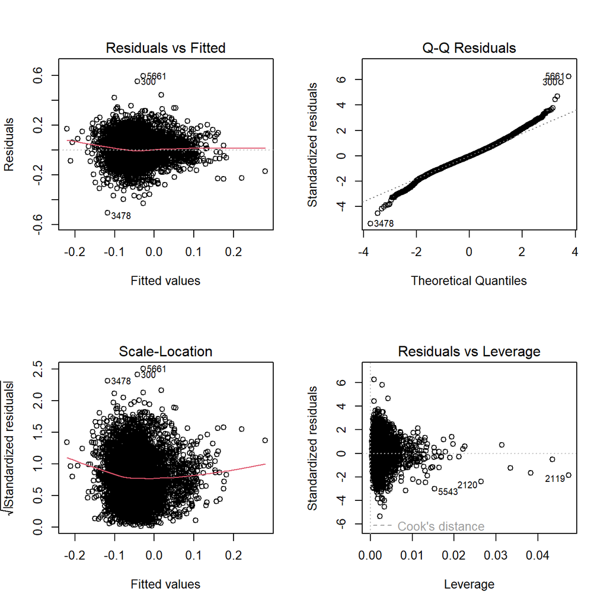

```r
par(mfrow = c(2, 2))
plot(mlr.fit)
```

```r
par(mfrow = c(1, 1))
```

The diagnostic plots the labs list but never run. Residuals against fitted values show no curve and roughly constant spread; the Q-Q plot has heavier tails than a normal — a handful of very dear or very cheap district-quarters — but nothing that bends the line; no point approaches a Cook’s distance that would change the fit if removed. The linear model is a fair description, with the caveat that the extremes are under-predicted in both directions.

```r
pred_mlr <- predict(mlr.fit, newdata = test_drv)
m_mlr    <- test_metrics(pred_mlr, test_drv$rel_log_cost_m2)
results  <- add_result(results, "Multiple linear regression", "drivers",
                       summary(mlr.fit)$r.squared, summary(mlr.fit)$adj.r.squared, m_mlr)
paste("The test MSE of the MLR model is", round(m_mlr[["test_MSE"]], 5))
```

```
## [1] "The test MSE of the MLR model is 0.01459"
```

Read the coefficient table with the correlation heatmap in mind: `avg_house_m2` and `rel_house_m2` carry opposite signs, and so do `log_houses_n` and `log_resid_alt_real`. That is the signature of collinearity — least squares has split the shared signal between the two members of each pair, and the individual coefficients should not be read as effect sizes. Section 4 is the remedy.

## 3.4 Adding the district

`ta` as a 67-level factor is the fixed-effects ceiling from section 2: it absorbs everything about a district that does not change over time. If the drivers were a full explanation of why dear districts are dear, adding `ta` would add nothing. `lm()` can hold a factor this size; the tree-based models in section 5 cannot, which is why they get `region` instead.

```r
train_ta <- df_train_c %>% dplyr::select(rel_log_cost_m2, all_of(drivers), ta)
test_ta  <- df_test_c  %>% dplyr::select(rel_log_cost_m2, all_of(drivers), ta)

mlr_ta.fit <- lm(rel_log_cost_m2 ~ ., data = train_ta)

cat("Adjusted R2, drivers only:    ", round(summary(mlr.fit)$adj.r.squared, 3), "\n")
```

```
## Adjusted R2, drivers only:     0.194
```

```r
cat("Adjusted R2, drivers + district:", round(summary(mlr_ta.fit)$adj.r.squared, 3), "\n")
```

```
## Adjusted R2, drivers + district: 0.401
```

```r
# the drivers' coefficients once district is held fixed (within-district effects)
std_coef(mlr_ta.fit, train_ta) %>%
  dplyr::filter(driver %in% drivers) %>%
  arrange(desc(abs(std_coefficient))) %>%
  mutate(across(-driver, ~ round(.x, 4))) %>%
  knitr::kable(caption = "Driver coefficients with district fixed effects (within-district)")
```

Driver coefficients with district fixed effects (within-district)

| driver | coefficient | std_coefficient |
| --- | --- | --- |
| log_resid_alt_real | 0.0280 | 0.0293 |
| rel_house_m2 | -0.1398 | -0.0221 |
| log_houses_n | 0.0185 | 0.0208 |
| avg_house_m2 | 0.0005 | 0.0167 |
| houses_yoy | -0.0180 | -0.0074 |
| dwell_per_1000 | 0.0009 | 0.0043 |
| multiunit_share | 0.0221 | 0.0034 |
| retire_share | -0.0307 | -0.0025 |
| apt_share | -0.0265 | -0.0019 |
| t_index | 0.0000 | 0.0008 |
| log_nonres_real | 0.0000 | -0.0001 |

```r
pred_mlr_ta <- predict(mlr_ta.fit, newdata = test_ta)
m_mlr_ta    <- test_metrics(pred_mlr_ta, test_ta$rel_log_cost_m2)
results     <- add_result(results, "Multiple linear regression", "drivers + district",
                          summary(mlr_ta.fit)$r.squared, summary(mlr_ta.fit)$adj.r.squared, m_mlr_ta)
paste("The test MSE of the MLR + district model is", round(m_mlr_ta[["test_MSE"]], 5))
```

```
## [1] "The test MSE of the MLR + district model is 0.01179"
```

The district dummies lift the fit well above the drivers alone, which answers part of RQ1 on its own: the measured drivers explain some of the gap between districts, but a large share is a location premium they do not capture. The within-district coefficients are the more trustworthy reading of each driver, because they compare a district with itself over time rather than Queenstown with Ōpōtiki.

## 3.5 Forward selection

Which drivers earn their place? Module 2’s recipe: `regsubsets()` builds the best model of each size by forward selection, and the size is chosen on data the model did not see. Instead of a random validation set we hold out the last four training years (2016–2019), because the test set is also “the future”.

```r
# inner split: fit on 1996-2015, choose the size on 2016-2019
inner_fit   <- df_train_c %>% dplyr::filter(year <= 2015) %>% dplyr::select(rel_log_cost_m2, all_of(drivers))
inner_valid <- df_train_c %>% dplyr::filter(year >  2015) %>% dplyr::select(rel_log_cost_m2, all_of(drivers))

fwd.fit <- regsubsets(rel_log_cost_m2 ~ ., data = inner_fit,
                      nvmax = length(drivers), method = "forward")
fwd_summary <- summary(fwd.fit)

# validation MSE for each model size, the way Lab M2 does it
make_predictions <- function(object, newdata, size) {
  form  <- as.formula(object$call[[2]])
  mat   <- model.matrix(form, newdata)
  coefi <- coef(object, id = size)
  mat[, names(coefi)] %*% coefi
}

valid_mse <- sapply(1:length(drivers), function(size) {
  pred <- make_predictions(fwd.fit, inner_valid, size)
  mean((inner_valid$rel_log_cost_m2 - pred)^2)
})

best_size <- which.min(valid_mse)
tibble(size = 1:length(drivers), valid_MSE = valid_mse,
       adj_R2 = fwd_summary$adjr2, BIC = fwd_summary$bic) %>%
  mutate(across(-size, ~ round(.x, 5))) %>%
  knitr::kable(caption = "Forward selection: validation MSE (2016-2019), adjusted R2 and BIC by model size")
```

Forward selection: validation MSE (2016-2019), adjusted R2 and BIC by model size

| size | valid_MSE | adj_R2 | BIC |
| --- | --- | --- | --- |
| 1 | 0.01020 | 0.10632 | -515.3147 |
| 2 | 0.00945 | 0.13447 | -659.0951 |
| 3 | 0.00883 | 0.15110 | -743.3165 |
| 4 | 0.00969 | 0.16407 | -808.6435 |
| 5 | 0.00957 | 0.16707 | -818.1917 |
| 6 | 0.00964 | 0.16952 | -824.6316 |
| 7 | 0.00965 | 0.17055 | -823.0404 |
| 8 | 0.00965 | 0.17076 | -816.7912 |
| 9 | 0.00947 | 0.17073 | -809.1279 |
| 10 | 0.00949 | 0.17061 | -801.0228 |
| 11 | 0.00951 | 0.17049 | -792.8601 |

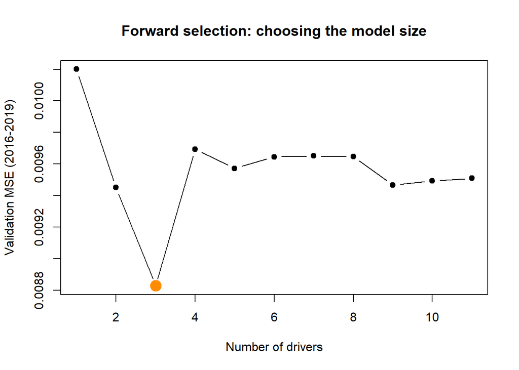

```r
plot(1:length(drivers), valid_mse, type = "b", pch = 19,
     xlab = "Number of drivers", ylab = "Validation MSE (2016-2019)",
     main = "Forward selection: choosing the model size")
points(best_size, valid_mse[best_size], col = "darkorange", pch = 19, cex = 2)
```

```r
cat("Size with the lowest validation MSE:", best_size, "\n")
```

```
## Size with the lowest validation MSE: 3
```

```r
cat("Order in which forward selection added the drivers:\n")
```

```
## Order in which forward selection added the drivers:
```

```r
print(apply(fwd_summary$which[, -1], 1, function(r) paste(names(r)[r], collapse = ", ")))
```

```
##                                                                                                                                                              1
##                                                                                                                                           "log_resid_alt_real"
##                                                                                                                                                              2
##                                                                                                                           "dwell_per_1000, log_resid_alt_real"
##                                                                                                                                                              3
##                                                                                                             "log_houses_n, dwell_per_1000, log_resid_alt_real"
##                                                                                                                                                              4
##                                                                                                    "t_index, log_houses_n, dwell_per_1000, log_resid_alt_real"
##                                                                                                                                                              5
##                                                                                      "t_index, rel_house_m2, log_houses_n, dwell_per_1000, log_resid_alt_real"
##                                                                                                                                                              6
##                                                                     "t_index, rel_house_m2, log_houses_n, multiunit_share, dwell_per_1000, log_resid_alt_real"
##                                                                                                                                                              7
##                                                    "t_index, rel_house_m2, log_houses_n, multiunit_share, dwell_per_1000, log_resid_alt_real, log_nonres_real"
##                                                                                                                                                              8
##                                         "t_index, rel_house_m2, log_houses_n, multiunit_share, apt_share, dwell_per_1000, log_resid_alt_real, log_nonres_real"
##                                                                                                                                                              9
##                           "t_index, avg_house_m2, rel_house_m2, log_houses_n, multiunit_share, apt_share, dwell_per_1000, log_resid_alt_real, log_nonres_real"
##                                                                                                                                                             10
##             "t_index, avg_house_m2, rel_house_m2, log_houses_n, multiunit_share, apt_share, retire_share, dwell_per_1000, log_resid_alt_real, log_nonres_real"
##                                                                                                                                                             11
## "t_index, avg_house_m2, rel_house_m2, log_houses_n, multiunit_share, apt_share, retire_share, dwell_per_1000, houses_yoy, log_resid_alt_real, log_nonres_real"
```

```r
# refit the chosen size on all training rows and test it once
chosen <- names(coef(fwd.fit, id = best_size))[-1]
fwd_best.fit <- lm(reformulate(chosen, response = "rel_log_cost_m2"), data = train_drv)
pred_fwd <- predict(fwd_best.fit, newdata = test_drv)
m_fwd    <- test_metrics(pred_fwd, test_drv$rel_log_cost_m2)
results  <- add_result(results, paste0("Forward selection (", best_size, " drivers)"), "drivers",
                       summary(fwd_best.fit)$r.squared, summary(fwd_best.fit)$adj.r.squared, m_fwd)
paste("The test MSE of the forward-selected model is", round(m_fwd[["test_MSE"]], 5))
```

```
## [1] "The test MSE of the forward-selected model is 0.01506"
```

## 3.6 Two transformations worth a look

Module 2 adds terms inside the formula rather than new columns. Two are suggested by section 2: population pressure may act with diminishing returns (a squared term), and alteration spending may matter more in a district that is also building a lot (an interaction).

```r
mlr_poly.fit <- lm(rel_log_cost_m2 ~ . - dwell_per_1000 + poly(dwell_per_1000, 2), data = train_drv)
mlr_int.fit  <- lm(rel_log_cost_m2 ~ . + log_resid_alt_real:log_houses_n, data = train_drv)

tibble(model = c("MLR, drivers", "+ poly(dwell_per_1000, 2)", "+ log_resid_alt_real:log_houses_n"),
       adj_R2 = c(summary(mlr.fit)$adj.r.squared,
                  summary(mlr_poly.fit)$adj.r.squared,
                  summary(mlr_int.fit)$adj.r.squared),
       test_MSE = c(m_mlr[["test_MSE"]],
                    test_metrics(predict(mlr_poly.fit, test_drv), test_drv$rel_log_cost_m2)[["test_MSE"]],
                    test_metrics(predict(mlr_int.fit,  test_drv), test_drv$rel_log_cost_m2)[["test_MSE"]])) %>%
  mutate(across(-model, ~ round(.x, 5))) %>%
  knitr::kable(caption = "Two transformations against the plain MLR")
```

Two transformations against the plain MLR

| model | adj_R2 | test_MSE |
| --- | --- | --- |
| MLR, drivers | 0.19362 | 0.01459 |
| + poly(dwell_per_1000, 2) | 0.19478 | 0.01452 |
| + log_resid_alt_real:log_houses_n | 0.19386 | 0.01454 |

```r
# R names the term in formula order (log_houses_n:log_resid_alt_real), so find it by pattern
int_coef <- summary(mlr_int.fit)$coefficients
int_coef[grepl("log_houses_n.*log_resid_alt_real|log_resid_alt_real.*log_houses_n", rownames(int_coef)), , drop = FALSE]
```

```
##                                     Estimate   Std. Error   t value  Pr(>|t|)
## log_houses_n:log_resid_alt_real -0.001130011 0.0006917808 -1.633481 0.1024232
```

Neither transformation is kept in the headline model unless it moves the test MSE by more than the models in section 4 differ from each other — the reader should judge that from the table. The interaction’s sign is worth noting even if small: a negative value says the alteration premium is weaker in districts that are already building a lot, which is consistent with Niwesh’s partial dependence plot (his fig25).

*Eleven correlated drivers and a model that splits their credit arbitrarily — can shrinkage give a steadier answer?*

# 4 Ridge and lasso

Both fit the same linear model as section 3 but add a penalty on the size of the coefficients. The tuning parameter $\lambda$ sets how hard the penalty bites; $\lambda = 0$ is ordinary least squares.

$$\text{Ridge:}\quad \min_b \;
\Sigma_{i=1}^{n}\Big(y_i - b_0 - \Sigma_{j=1}^{p} b_j x_{ij}\Big)^2 +
\lambda \Sigma_{j=1}^{p} b_j^2$$

$$\text{Lasso:}\quad \min_b \;
\Sigma_{i=1}^{n}\Big(y_i - b_0 - \Sigma_{j=1}^{p} b_j x_{ij}\Big)^2 +
\lambda \Sigma_{j=1}^{p} |b_j|$$

The squared penalty shrinks every coefficient towards zero but never to zero; the absolute penalty can set coefficients exactly to zero, so the lasso also selects. With a correlated pair, ridge tends to share the effect between the two; the lasso tends to keep one and drop the other. This is the ISLR2 §6.5 recipe with `glmnet`, the one package here that is not in a course lab.

## 4.1 Set up

`glmnet()` wants a numeric matrix and standardises the columns itself (`standardize = TRUE` is the default), so the penalty treats every driver equally whatever its units.

```r
x_train <- model.matrix(rel_log_cost_m2 ~ ., data = train_drv)[, -1]   # drop the intercept column
y_train <- train_drv$rel_log_cost_m2
x_test  <- model.matrix(rel_log_cost_m2 ~ ., data = test_drv)[, -1]
y_test  <- test_drv$rel_log_cost_m2

dim(x_train)
```

```
## [1] 5696   11
```

## 4.2 Choosing lambda with time-ordered folds

`cv.glmnet()` picks $\lambda$ by cross-validation. Its default folds are random, which would again let later quarters inform earlier ones. We hand it folds made of year blocks instead — five contiguous blocks of the training years — so each fold is validated on years its training folds did not see.

```r
# five contiguous year blocks: 1996-2003, 2004-07, 2008-11, 2012-15, 2016-19
foldid <- cut(df_train_c$year, breaks = c(1995, 2003, 2007, 2011, 2015, 2019), labels = FALSE)
table(foldid)
```

```
## foldid
##    1    2    3    4    5
## 1807 1009  979  931  970
```

```r
cv.ridge <- cv.glmnet(x_train, y_train, alpha = 0, foldid = foldid)
cv.lasso <- cv.glmnet(x_train, y_train, alpha = 1, foldid = foldid)

cat(sprintf("Ridge: lambda.min = %.5f, lambda.1se = %.5f\n", cv.ridge$lambda.min, cv.ridge$lambda.1se))
```

```
## Ridge: lambda.min = 0.00368, lambda.1se = 0.13837
```

```r
cat(sprintf("Lasso: lambda.min = %.5f, lambda.1se = %.5f\n", cv.lasso$lambda.min, cv.lasso$lambda.1se))
```

```
## Lasso: lambda.min = 0.00004, lambda.1se = 0.01450
```

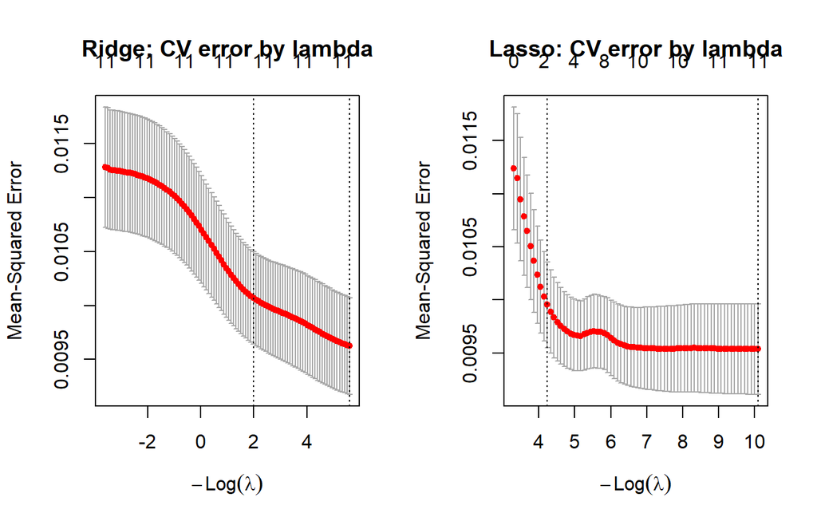

```r
par(mfrow = c(1, 2))
plot(cv.ridge, main = "Ridge: CV error by lambda")
plot(cv.lasso, main = "Lasso: CV error by lambda")
```

```r
par(mfrow = c(1, 1))
```

Two values of $\lambda$ are marked on each curve: `lambda.min`, where the CV error is lowest, and `lambda.1se`, the largest $\lambda$ whose error is within one standard error of that minimum — the simplest model that is not measurably worse. We report both. Note how far apart they are here (ridge 0.0037 against 0.138; lasso 0.00004 against 0.0145): with only five time-block folds, and folds that differ from each other in how hard they are to predict, the standard error of the CV curve is wide, and “within one SE” is a generous margin. Section 4.5 shows what that costs on the test set. The numbers on top of the lasso plot are how many drivers are still non-zero.

## 4.3 Coefficient paths

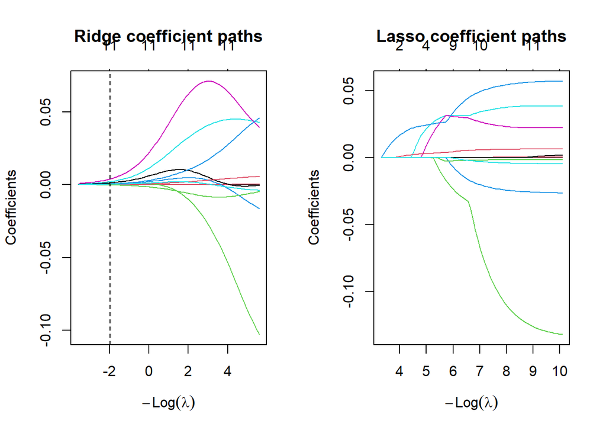

```r
ridge.fit <- glmnet(x_train, y_train, alpha = 0)
lasso.fit <- glmnet(x_train, y_train, alpha = 1)

par(mfrow = c(1, 2))
plot(ridge.fit, xvar = "lambda", label = TRUE, main = "Ridge coefficient paths")
abline(v = log(cv.ridge$lambda.1se), lty = 2)
plot(lasso.fit, xvar = "lambda", label = TRUE, main = "Lasso coefficient paths")
abline(v = log(cv.lasso$lambda.1se), lty = 2)
```

```r
par(mfrow = c(1, 1))

# which number is which driver on the plots
tibble(label = seq_along(colnames(x_train)), driver = colnames(x_train)) %>%
  knitr::kable(caption = "Curve labels on the path plots")
```

Curve labels on the path plots

| label | driver |
| --- | --- |
| 1 | t_index |
| 2 | avg_house_m2 |
| 3 | rel_house_m2 |
| 4 | log_houses_n |
| 5 | multiunit_share |
| 6 | apt_share |
| 7 | retire_share |
| 8 | dwell_per_1000 |
| 9 | houses_yoy |
| 10 | log_resid_alt_real |
| 11 | log_nonres_real |

## 4.4 Which drivers survive?

The table the poster needs: OLS, ridge and lasso side by side, standardised so the sizes compare. A coefficient of 0 in the lasso columns means the driver was dropped.

```r
x_sd <- apply(x_train, 2, sd)

coef_at <- function(cvfit, s) as.vector(coef(cvfit, s = s))[-1]   # drop the intercept

coef_table <- tibble(driver = colnames(x_train),
                     OLS = coef(mlr.fit)[colnames(x_train)],
                     `Ridge (1se)` = coef_at(cv.ridge, "lambda.1se"),
                     `Ridge (min)` = coef_at(cv.ridge, "lambda.min"),
                     `Lasso (1se)` = coef_at(cv.lasso, "lambda.1se"),
                     `Lasso (min)` = coef_at(cv.lasso, "lambda.min")) %>%
  mutate(across(-driver, ~ .x * x_sd))   # per one SD of the driver

coef_table %>%
  arrange(desc(abs(`Lasso (1se)`)), desc(abs(`Ridge (1se)`))) %>%
  mutate(across(-driver, ~ round(.x, 4))) %>%
  knitr::kable(caption = "Standardised coefficients (change in relative cost per one SD of the driver)")
```

Standardised coefficients (change in relative cost per one SD of the driver)

| driver | OLS | Ridge (1se) | Ridge (min) | Lasso (1se) | Lasso (min) |
| --- | --- | --- | --- | --- | --- |
| log_resid_alt_real | 0.0605 | 0.0107 | 0.0478 | 0.0208 | 0.0599 |
| dwell_per_1000 | 0.0300 | 0.0089 | 0.0257 | 0.0078 | 0.0298 |
| log_houses_n | -0.0301 | 0.0053 | -0.0184 | 0.0000 | -0.0296 |
| multiunit_share | 0.0059 | 0.0049 | 0.0066 | 0.0000 | 0.0059 |
| apt_share | 0.0016 | 0.0046 | 0.0029 | 0.0000 | 0.0016 |
| log_nonres_real | -0.0071 | 0.0027 | -0.0060 | 0.0000 | -0.0070 |
| houses_yoy | -0.0006 | -0.0024 | -0.0020 | 0.0000 | -0.0006 |
| t_index | 0.0042 | 0.0021 | 0.0044 | 0.0000 | 0.0042 |
| rel_house_m2 | -0.0215 | -0.0016 | -0.0162 | 0.0000 | -0.0209 |
| avg_house_m2 | 0.0157 | 0.0010 | 0.0112 | 0.0000 | 0.0151 |
| retire_share | 0.0002 | 0.0008 | 0.0000 | 0.0000 | 0.0001 |

```r
cat("Drivers the lasso sets to zero at lambda.1se:",
    paste(coef_table$driver[coef_table$`Lasso (1se)` == 0], collapse = ", "), "\n")
```

```
## Drivers the lasso sets to zero at lambda.1se: t_index, avg_house_m2, rel_house_m2, log_houses_n, multiunit_share, apt_share, retire_share, houses_yoy, log_nonres_real
```

```r
cat("Drivers the lasso sets to zero at lambda.min:",
    paste(coef_table$driver[coef_table$`Lasso (min)` == 0], collapse = ", "), "\n")
```

```
## Drivers the lasso sets to zero at lambda.min:
```

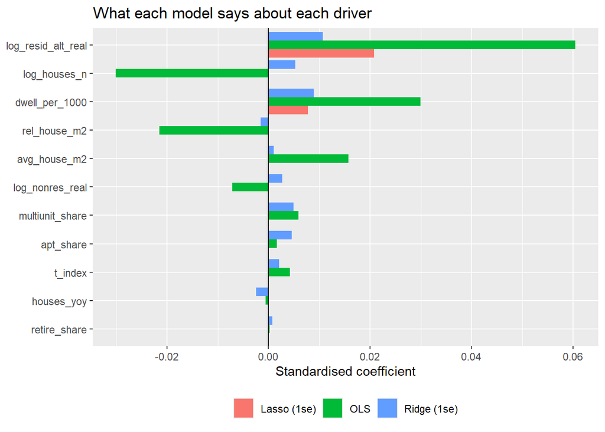

```r
coef_table %>%
  dplyr::select(driver, OLS, `Ridge (1se)`, `Lasso (1se)`) %>%
  pivot_longer(-driver, names_to = "model", values_to = "std_coefficient") %>%
  mutate(driver = fct_reorder(driver, abs(std_coefficient), .fun = max)) %>%
  ggplot(aes(x = driver, y = std_coefficient, fill = model)) +
  geom_col(position = "dodge") +
  coord_flip() +
  geom_hline(yintercept = 0) +
  labs(title = "What each model says about each driver",
       x = NULL, y = "Standardised coefficient", fill = NULL) +
  theme(legend.position = "bottom")
```

Look first at the two correlated pairs from section 2. Under OLS `log_houses_n` and `log_resid_alt_real` carry opposite signs (−0.030 and +0.061 per SD); ridge at `lambda.1se` pulls them to the same sign (+0.005 and +0.011) by sharing the credit; the lasso at `lambda.1se` keeps alteration spending and sets the house count to zero. The house-size pair goes the same way: OLS gives them opposite signs, ridge shrinks both to nearly nothing, the lasso drops both. At `lambda.1se` the lasso keeps exactly two drivers — `log_resid_alt_real` and `dwell_per_1000` — the first two that forward selection chose; at `lambda.min` it keeps all eleven and its coefficients are within 0.001 of OLS. So the two penalised models agree with each other and with section 3.5 on what matters, and that agreement, not any single coefficient, is the answer to “which parameters are important”: alteration spending and population pressure are the drivers of relative cost the data will support in a linear model, with the number of houses a distant third.

## 4.5 Test performance

```r
for (nm in c("lambda.1se", "lambda.min")) {
  m_r <- test_metrics(as.vector(predict(cv.ridge, newx = x_test, s = nm)), y_test)
  m_l <- test_metrics(as.vector(predict(cv.lasso, newx = x_test, s = nm)), y_test)
  results <- add_result(results, paste0("Ridge (", nm, ")"), "drivers", metrics = m_r)
  results <- add_result(results, paste0("Lasso (", nm, ")"), "drivers", metrics = m_l)
}

results %>%
  dplyr::filter(set == "drivers") %>%
  mutate(across(where(is.numeric), ~ round(.x, 5))) %>%
  knitr::kable(caption = "Drivers-only models so far: training fit and test error")
```

Drivers-only models so far: training fit and test error

| model | set | train_R2 | adj_R2 | test_MSE | test_RMSE | test_R2 |
| --- | --- | --- | --- | --- | --- | --- |
| Multiple linear regression | drivers | 0.19518 | 0.19362 | 0.01459 | 0.12079 | 0.21339 |
| Forward selection (3 drivers) | drivers | 0.17927 | 0.17884 | 0.01506 | 0.12272 | 0.18804 |
| Ridge (lambda.1se) | drivers | NA | NA | 0.01618 | 0.12720 | 0.12775 |
| Lasso (lambda.1se) | drivers | NA | NA | 0.01669 | 0.12917 | 0.10050 |
| Ridge (lambda.min) | drivers | NA | NA | 0.01468 | 0.12117 | 0.20844 |
| Lasso (lambda.min) | drivers | NA | NA | 0.01458 | 0.12073 | 0.21418 |

At `lambda.min`, ridge and lasso test within a hair of OLS (0.01468 and 0.01458 against 0.01459): with eleven drivers and over five thousand rows the model is not over-fitted, so there is nothing for the penalty to fix. At `lambda.1se` both are clearly worse (0.01618 and 0.01669; test $R^2$ falls from 0.21 to 0.13 and 0.10) — the one-SE rule, applied to a CV curve with wide standard errors, threw away real signal. The lesson for this dataset is to use `lambda.min` when the model has to predict, and to use the lasso’s *path* — the order in which drivers enter as $\lambda$ falls — when the question is which drivers matter. The gain from shrinkage here is in reading the coefficients, not in the error.

## 4.6 Ridge and lasso with region

```r
train_reg <- df_train_c %>% dplyr::select(rel_log_cost_m2, all_of(drivers), region)
test_reg  <- df_test_c  %>% dplyr::select(rel_log_cost_m2, all_of(drivers), region)

x_train_reg <- model.matrix(rel_log_cost_m2 ~ ., data = train_reg)[, -1]
x_test_reg  <- model.matrix(rel_log_cost_m2 ~ ., data = test_reg)[, -1]

cv.ridge.reg <- cv.glmnet(x_train_reg, y_train, alpha = 0, foldid = foldid)
cv.lasso.reg <- cv.glmnet(x_train_reg, y_train, alpha = 1, foldid = foldid)

for (nm in c("lambda.1se", "lambda.min")) {
  m_r <- test_metrics(as.vector(predict(cv.ridge.reg, newx = x_test_reg, s = nm)), y_test)
  m_l <- test_metrics(as.vector(predict(cv.lasso.reg, newx = x_test_reg, s = nm)), y_test)
  results <- add_result(results, paste0("Ridge (", nm, ")"), "drivers + region", metrics = m_r)
  results <- add_result(results, paste0("Lasso (", nm, ")"), "drivers + region", metrics = m_l)
}

# the region dummies the lasso keeps, and the driver coefficients once region is in
lasso_reg_coef <- as.vector(coef(cv.lasso.reg, s = "lambda.1se"))[-1]
names(lasso_reg_coef) <- colnames(x_train_reg)

cat("Region dummies kept by the lasso at lambda.1se:\n")
```

```
## Region dummies kept by the lasso at lambda.1se:
```

```r
print(round(lasso_reg_coef[grepl("^region", names(lasso_reg_coef)) & lasso_reg_coef != 0], 4))
```

```
##        regionHawke's Bay Region regionManawatu-Whanganui Region
##                          0.0140                         -0.0095
##         regionWellington Region
##                          0.0249
```

```r
results %>%
  dplyr::filter(grepl("Ridge|Lasso", model)) %>%
  arrange(set, model) %>%
  mutate(across(where(is.numeric), ~ round(.x, 5))) %>%
  knitr::kable(caption = "Ridge and lasso: drivers only vs drivers + region")
```

Ridge and lasso: drivers only vs drivers + region

| model | set | train_R2 | adj_R2 | test_MSE | test_RMSE | test_R2 |
| --- | --- | --- | --- | --- | --- | --- |
| Lasso (lambda.1se) | drivers | NA | NA | 0.01669 | 0.12917 | 0.10050 |
| Lasso (lambda.min) | drivers | NA | NA | 0.01458 | 0.12073 | 0.21418 |
| Ridge (lambda.1se) | drivers | NA | NA | 0.01618 | 0.12720 | 0.12775 |
| Ridge (lambda.min) | drivers | NA | NA | 0.01468 | 0.12117 | 0.20844 |
| Lasso (lambda.1se) | drivers + region | NA | NA | 0.01589 | 0.12605 | 0.14346 |
| Lasso (lambda.min) | drivers + region | NA | NA | 0.01356 | 0.11646 | 0.26887 |
| Ridge (lambda.1se) | drivers + region | NA | NA | 0.01507 | 0.12277 | 0.18744 |
| Ridge (lambda.min) | drivers + region | NA | NA | 0.01357 | 0.11648 | 0.26854 |

The regions the lasso keeps are the ones whose premium or discount the drivers cannot account for; the regions it drops are explained by their drivers. Three survive at `lambda.1se`: Wellington (+0.025) and Hawke’s Bay (+0.014) dearer than their drivers say, Manawatū-Whanganui (−0.010) cheaper. Auckland, Canterbury and Otago do not appear — their premiums are carried by the drivers, Auckland’s by population pressure and alteration spending in particular. With region in, ridge and lasso at `lambda.min` test at 0.01357, between the drivers-only MLR (0.01459) and the district model (0.01179): the 17 regions recover about a third of what the 67 districts know. That list is a compact answer to the “location premium” half of RQ1 and sits naturally beside the district ranking from section 2.

*The linear family has had its say. Do models that can find thresholds and interactions on their own — trees — see anything the straight lines missed?*

# 5 Tree-based models

Trees split the data on one driver at a time, so they find thresholds and interactions without being told where to look, and they are indifferent to the collinearity that troubled section 3. Their weakness is the opposite of the linear model’s: a tree can only predict values it has seen, so it cannot follow a trend out of the training years. The models here are fitted on the drivers plus `region` — `tree()` caps a factor at 32 levels and `randomForest()` at 53, so the 67-level `ta` cannot go in. Module 6’s recipe throughout.

```r
# short region codes, so a split on several regions fits on the tree plot
region_short <- c("Northland Region" = "Nthld", "Auckland Region" = "Akl",
                  "Waikato Region" = "Wkto", "Bay of Plenty Region" = "BoP",
                  "Gisborne Region" = "Gis", "Hawke's Bay Region" = "HB",
                  "Taranaki Region" = "Tnki", "Manawatu-Whanganui Region" = "MWh",
                  "Wellington Region" = "Wgtn", "Tasman Region" = "Tas",
                  "Nelson Region" = "Nsn", "Marlborough Region" = "Marl",
                  "West Coast Region" = "WC", "Canterbury Region" = "Cant",
                  "Otago Region" = "Otago", "Southland Region" = "Sthld",
                  "Area Outside Region" = "Chat")

# data.frames rather than tibbles: gbm() in particular wants the base class
train_tree <- as.data.frame(train_reg) %>%
  mutate(region = factor(region_short[as.character(region)], levels = unname(region_short)))
test_tree  <- as.data.frame(test_reg) %>%
  mutate(region = factor(region_short[as.character(region)], levels = unname(region_short)))

stopifnot(!anyNA(train_tree$region), !anyNA(test_tree$region))

tibble(code = unname(region_short), region = names(region_short)) %>%
  knitr::kable(caption = "Region codes used in the tree plots")
```

Region codes used in the tree plots

| code | region |
| --- | --- |
| Nthld | Northland Region |
| Akl | Auckland Region |
| Wkto | Waikato Region |
| BoP | Bay of Plenty Region |
| Gis | Gisborne Region |
| HB | Hawke’s Bay Region |
| Tnki | Taranaki Region |
| MWh | Manawatu-Whanganui Region |
| Wgtn | Wellington Region |
| Tas | Tasman Region |
| Nsn | Nelson Region |
| Marl | Marlborough Region |
| WC | West Coast Region |
| Cant | Canterbury Region |
| Otago | Otago Region |
| Sthld | Southland Region |
| Chat | Area Outside Region |

## 5.1 Regression tree

```r
tree.fit <- tree(rel_log_cost_m2 ~ ., data = train_tree)
summary(tree.fit)
```

```
##
## Regression tree:
## tree(formula = rel_log_cost_m2 ~ ., data = train_tree)
## Variables actually used in tree construction:
## [1] "log_resid_alt_real" "region"             "t_index"
## [4] "dwell_per_1000"
## Number of terminal nodes:  11
## Residual mean deviance:  0.008037 = 45.69 / 5685
## Distribution of residuals:
##     Min.  1st Qu.   Median     Mean  3rd Qu.     Max.
## -0.53070 -0.05450 -0.00128  0.00000  0.05355  0.58940
```

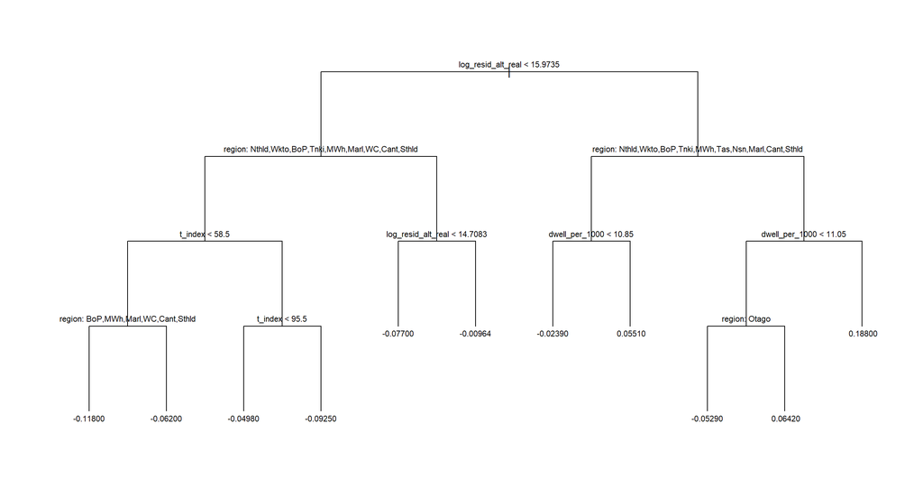

```r
# type = "uniform" gives every level the same height; the default scales branch
# length by deviance, which leaves the first split with the whole canvas
plot(tree.fit, type = "uniform")
text(tree.fit, pretty = 0, cex = 0.7, digits = 3)
```

The first split is the plain-language headline of the tree: whichever driver sits at the top is the single most useful yes/no question about a district-quarter. The leaves are mean relative costs for the rows that reach them. A split on `region` lists the codes that go left; everything else goes right. Branch lengths carry no information in this layout; the node listing below gives each split’s rows, deviance and mean, which is where the worth of a split is read.

```r
tree.fit
```

```
## node), split, n, deviance, yval
##       * denotes terminal node
##
##  1) root 5696 63.4700 -0.040890
##    2) log_resid_alt_real < 15.9735 4164 41.0100 -0.062200
##      4) region: Nthld,Wkto,BoP,Tnki,MWh,Marl,WC,Cant,Sthld 2915 26.5700 -0.078120
##        8) t_index < 58.5 990  8.5940 -0.099970
##         16) region: BoP,MWh,Marl,WC,Cant,Sthld 675  5.7490 -0.117700 *
##         17) region: Nthld,Wkto,Tnki 315  2.1770 -0.061980 *
##        9) t_index > 58.5 1925 17.2600 -0.066880
##         18) t_index < 95.5 1156  9.4380 -0.049810 *
##         19) t_index > 95.5 769  6.9740 -0.092540 *
##      5) region: Gis,HB,Wgtn,Tas,Nsn,Otago,Chat 1249 11.9900 -0.025050
##       10) log_resid_alt_real < 14.7083 286  3.5680 -0.076960 *
##       11) log_resid_alt_real > 14.7083 963  7.4180 -0.009637 *
##    3) log_resid_alt_real > 15.9735 1532 15.4200  0.017030
##      6) region: Nthld,Wkto,BoP,Tnki,MWh,Tas,Nsn,Marl,Cant,Sthld 939  8.0440 -0.011370
##       12) dwell_per_1000 < 10.85 790  5.7690 -0.023910 *
##       13) dwell_per_1000 > 10.85 149  1.4920  0.055120 *
##      7) region: Akl,Gis,HB,Wgtn,Otago 593  5.4240  0.062020
##       14) dwell_per_1000 < 11.05 520  3.2630  0.044350
##         28) region: Otago 88  0.2760 -0.052950 *
##         29) region: Akl,Gis,HB,Wgtn 432  1.9840  0.064170 *
##       15) dwell_per_1000 > 11.05 73  0.8421  0.187900 *
```

Module 6 prunes with cross-validation: grow the full tree, ask how the deviance changes with the number of leaves, and cut back to the size with the lowest CV deviance.

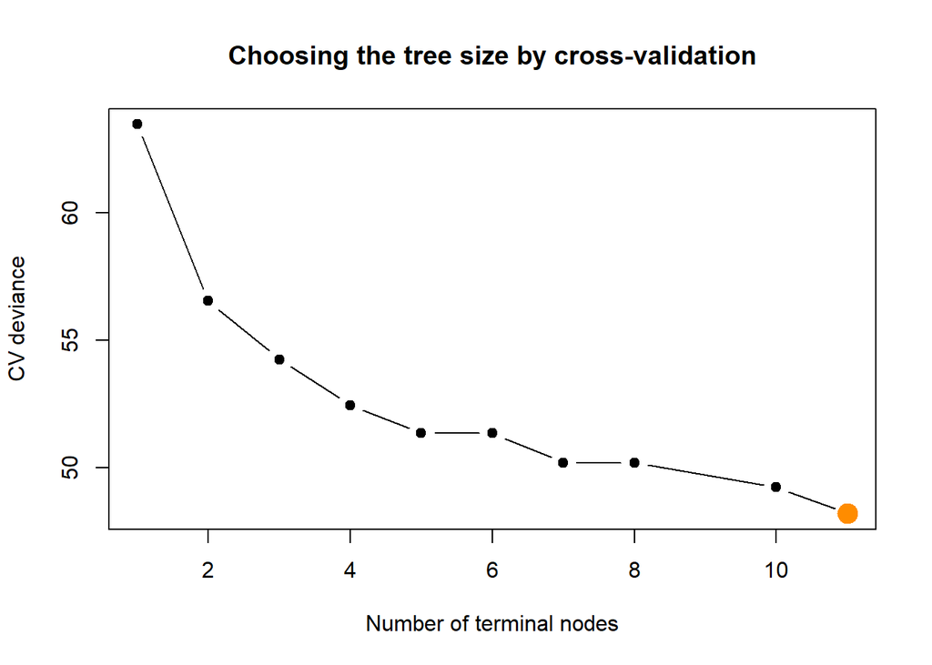

```r
set.seed(462)
cv.reg <- cv.tree(tree.fit)
best.size <- cv.reg$size[which.min(cv.reg$dev)]

plot(cv.reg$size, cv.reg$dev, type = "b", pch = 19,
     xlab = "Number of terminal nodes", ylab = "CV deviance",
     main = "Choosing the tree size by cross-validation")
points(best.size, min(cv.reg$dev), col = "darkorange", pch = 19, cex = 2)
```

```r
cat("Tree size with the lowest CV deviance:", best.size, "\n")
```

```
## Tree size with the lowest CV deviance: 11
```

```r
pruned.tree <- prune.tree(tree.fit, best = best.size)

pred_tree   <- predict(tree.fit,    newdata = test_tree)
pred_pruned <- predict(pruned.tree, newdata = test_tree)
m_tree   <- test_metrics(pred_tree,   test_tree$rel_log_cost_m2)
m_pruned <- test_metrics(pred_pruned, test_tree$rel_log_cost_m2)

results <- add_result(results, "Regression tree (full)",   "drivers + region", metrics = m_tree)
results <- add_result(results, paste0("Regression tree (pruned, ", best.size, " leaves)"),
                      "drivers + region", metrics = m_pruned)
paste("Test MSE: full tree", round(m_tree[["test_MSE"]], 5),
      " pruned tree", round(m_pruned[["test_MSE"]], 5))
```

```
## [1] "Test MSE: full tree 0.01413  pruned tree 0.01413"
```

If the CV curve chose the full tree, pruning changes nothing and the two rows are identical — that happens when `tree()`’s default stopping rule already grew a modest tree. A single tree is easy to read and usually the weakest predictor in this section; it is here for the picture, and as the building block of the next two models.

## 5.2 Bagging and random forest

Bagging grows many trees on bootstrap samples of the training rows and averages them; a random forest does the same but offers each split only a random subset of the drivers, which de-correlates the trees. In `randomForest()` the only difference is `mtry`: all predictors for bagging, about a third of them for a regression forest.

```r
num_predictors <- ncol(train_tree) - 1     # 11 drivers + region

set.seed(462)
bag.tree <- randomForest(rel_log_cost_m2 ~ ., data = train_tree,
                         mtry = num_predictors, ntree = 500, importance = TRUE)
set.seed(462)
rf.tree  <- randomForest(rel_log_cost_m2 ~ ., data = train_tree,
                         mtry = 4, ntree = 500, importance = TRUE)
bag.tree
```

```
##
## Call:
##  randomForest(formula = rel_log_cost_m2 ~ ., data = train_tree,      mtry = num_predictors, ntree = 500, importance = TRUE)
##                Type of random forest: regression
##                      Number of trees: 500
## No. of variables tried at each split: 12
##
##           Mean of squared residuals: 0.006126334
##                     % Var explained: 45.02
```

```r
rf.tree
```

```
##
## Call:
##  randomForest(formula = rel_log_cost_m2 ~ ., data = train_tree,      mtry = 4, ntree = 500, importance = TRUE)
##                Type of random forest: regression
##                      Number of trees: 500
## No. of variables tried at each split: 4
##
##           Mean of squared residuals: 0.006129046
##                     % Var explained: 45
```

The printed “% Var explained” is out-of-bag — each row predicted only by the trees that did not see it — so it is an honest training-side estimate without a validation set.

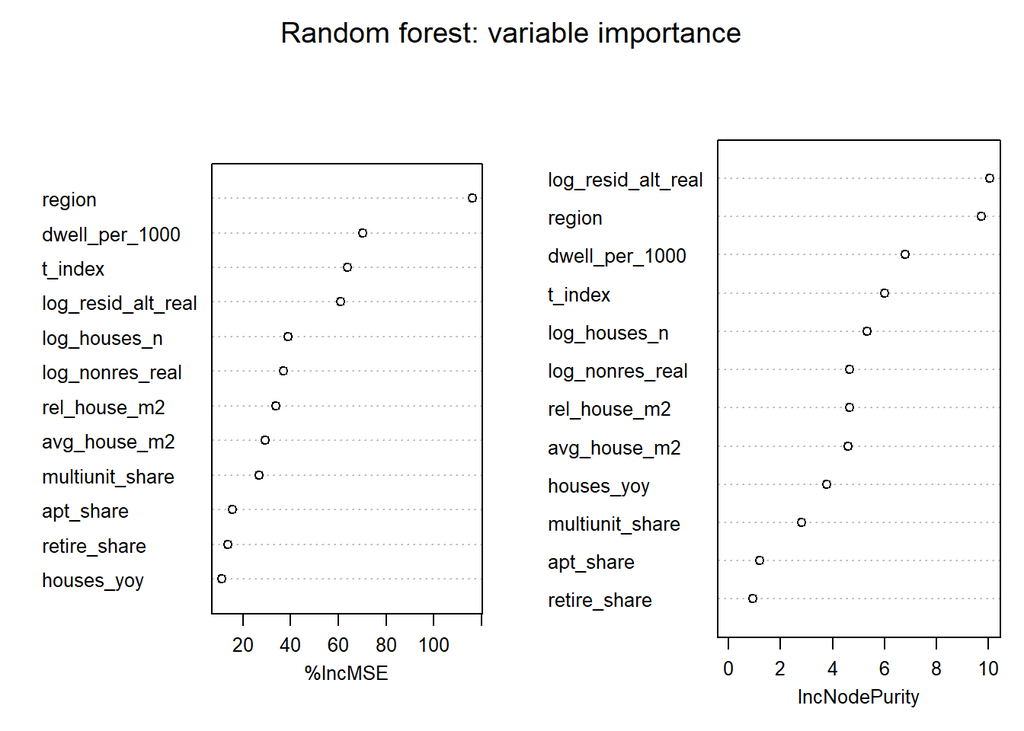

```r
varImpPlot(rf.tree, main = "Random forest: variable importance", cex = 0.8)
```

```r
importance(rf.tree) %>%
  as.data.frame() %>%
  rownames_to_column("driver") %>%
  arrange(desc(`%IncMSE`)) %>%
  mutate(across(-driver, ~ round(.x, 2))) %>%
  knitr::kable(caption = "Random forest importance: % increase in MSE when the driver is permuted, and node purity")
```

Random forest importance: % increase in MSE when the driver is permuted, and node purity

| driver | %IncMSE | IncNodePurity |
| --- | --- | --- |
| region | 116.15 | 9.72 |
| dwell_per_1000 | 70.32 | 6.78 |
| t_index | 63.83 | 6.00 |
| log_resid_alt_real | 61.07 | 10.05 |
| log_houses_n | 39.02 | 5.34 |
| log_nonres_real | 36.92 | 4.66 |
| rel_house_m2 | 33.99 | 4.65 |
| avg_house_m2 | 29.51 | 4.61 |
| multiunit_share | 26.82 | 2.83 |
| apt_share | 15.74 | 1.19 |
| retire_share | 13.65 | 0.94 |
| houses_yoy | 11.22 | 3.78 |

`%IncMSE` is the one to read: how much worse the out-of-bag predictions get when that driver’s values are shuffled. It is model-agnostic in spirit and the closest thing a forest has to the standardised coefficients of section 4, so the two rankings can be compared directly — a driver that is near the top in both the lasso table and here is important in any reasonable model.

```r
pred_bag <- predict(bag.tree, newdata = test_tree)
pred_rf  <- predict(rf.tree,  newdata = test_tree)
m_bag <- test_metrics(pred_bag, test_tree$rel_log_cost_m2)
m_rf  <- test_metrics(pred_rf,  test_tree$rel_log_cost_m2)

results <- add_result(results, "Bagging (mtry = 12)",       "drivers + region", metrics = m_bag)
results <- add_result(results, "Random forest (mtry = 4)",  "drivers + region", metrics = m_rf)
paste("Test MSE: bagging", round(m_bag[["test_MSE"]], 5), " random forest", round(m_rf[["test_MSE"]], 5))
```

```
## [1] "Test MSE: bagging 0.01134  random forest 0.0114"
```

## 5.3 Boosting

Boosting grows small trees one after another, each fitted to the residuals of the ensemble so far, scaled down by the shrinkage. For a continuous response the distribution is `"gaussian"`. Module 6 uses stumps (`interaction.depth = 1`); depth 2 lets each tree hold one interaction, which section 3 suggested exists.

```r
set.seed(462)
boost.fit <- gbm(rel_log_cost_m2 ~ ., data = train_tree,
                 distribution = "gaussian", n.trees = 1000,
                 interaction.depth = 2, shrinkage = 0.05, verbose = FALSE)

# relative influence: share of the total reduction in squared error attributed to each driver
summary(boost.fit, plotit = FALSE) %>%
  mutate(rel.inf = round(rel.inf, 2)) %>%
  knitr::kable(caption = "Boosting: relative influence of each driver")
```

Boosting: relative influence of each driver

|  | var | rel.inf |
| --- | --- | --- |
| region | region | 31.00 |
| log_resid_alt_real | log_resid_alt_real | 23.67 |
| dwell_per_1000 | dwell_per_1000 | 12.31 |
| t_index | t_index | 7.77 |
| avg_house_m2 | avg_house_m2 | 6.26 |
| rel_house_m2 | rel_house_m2 | 5.59 |
| log_nonres_real | log_nonres_real | 4.35 |
| log_houses_n | log_houses_n | 3.71 |
| houses_yoy | houses_yoy | 3.24 |
| multiunit_share | multiunit_share | 0.91 |
| retire_share | retire_share | 0.75 |
| apt_share | apt_share | 0.45 |

```r
pred_boost <- predict(boost.fit, newdata = test_tree, n.trees = 1000, type = "response")
m_boost <- test_metrics(pred_boost, test_tree$rel_log_cost_m2)
results <- add_result(results, "Boosting (1000 trees, depth 2)", "drivers + region", metrics = m_boost)
paste("The test MSE of the boosted model is", round(m_boost[["test_MSE"]], 5))
```

```
## [1] "The test MSE of the boosted model is 0.01224"
```

Three importance rankings now exist — lasso coefficients, forest `%IncMSE`, boosting relative influence. Section 6 puts them side by side.

## 5.4 Tuning the ensembles and the elastic net

The forest and the boosted model above use settings chosen by habit — `mtry = 4` and `nodesize = 5`; 1,000 trees at depth 2 with shrinkage 0.05 — and the ridge and lasso are the two endpoints of the elastic net. This section asks whether any of those choices matter, using the same five time-block folds as section 4.2 so that every setting is judged on years it did not see. The test set is not touched until one setting per model has been chosen.

```r
# blocked cross-validation: fit on four year-blocks, score on the fifth, repeat
cv_blocked <- function(fit_fun, pred_fun, data, foldid) {
  sapply(sort(unique(foldid)), function(k) {
    fit  <- fit_fun(data[foldid != k, ])
    pred <- pred_fun(fit, data[foldid == k, ])
    sqrt(mean((data$rel_log_cost_m2[foldid == k] - pred)^2))
  })
}
```

### 5.4.1 Random forest: `mtry` and `nodesize`

`nodesize` is the smallest leaf the forest is allowed to grow; small leaves memorise individual district-quarters, large ones average over them. `mtry` is how many drivers each split may choose from. Six combinations, 300 trees each inside the folds (enough to rank settings; the chosen one is refitted with 500).

```r
rf_grid <- expand.grid(mtry = c(4, 12), nodesize = c(5, 20, 50))

rf_cv <- map_dfr(seq_len(nrow(rf_grid)), function(i) {
  set.seed(462)
  fold_rmse <- cv_blocked(
    fit_fun  = function(d) randomForest(rel_log_cost_m2 ~ ., data = d, ntree = 300,
                                        mtry = rf_grid$mtry[i], nodesize = rf_grid$nodesize[i]),
    pred_fun = function(fit, d) predict(fit, newdata = d),
    data = train_tree, foldid = foldid)
  tibble(mtry = rf_grid$mtry[i], nodesize = rf_grid$nodesize[i],
         cv_RMSE = mean(fold_rmse), cv_RMSE_se = sd(fold_rmse) / sqrt(length(fold_rmse)))
})

rf_cv %>%
  arrange(cv_RMSE) %>%
  mutate(across(c(cv_RMSE, cv_RMSE_se), ~ round(.x, 5))) %>%
  knitr::kable(caption = "Random forest: blocked-CV RMSE by mtry and nodesize")
```

Random forest: blocked-CV RMSE by mtry and nodesize

| mtry | nodesize | cv_RMSE | cv_RMSE_se |
| --- | --- | --- | --- |
| 4 | 5 | 0.08625 | 0.00294 |
| 4 | 20 | 0.08640 | 0.00289 |
| 12 | 20 | 0.08667 | 0.00266 |
| 12 | 5 | 0.08675 | 0.00290 |
| 12 | 50 | 0.08702 | 0.00247 |
| 4 | 50 | 0.08712 | 0.00248 |

```r
rf_best <- rf_cv %>% arrange(cv_RMSE) %>% slice(1)
cat("Chosen: mtry =", rf_best$mtry, " nodesize =", rf_best$nodesize, "\n")
```

```
## Chosen: mtry = 4  nodesize = 5
```

```r
set.seed(462)
rf_tuned.tree <- randomForest(rel_log_cost_m2 ~ ., data = train_tree, ntree = 500,
                              mtry = rf_best$mtry, nodesize = rf_best$nodesize, importance = TRUE)

m_rf_tuned <- test_metrics(predict(rf_tuned.tree, newdata = test_tree), test_tree$rel_log_cost_m2)
results <- add_result(results, paste0("Random forest (tuned: mtry = ", rf_best$mtry,
                                      ", nodesize = ", rf_best$nodesize, ")"),
                      "drivers + region", metrics = m_rf_tuned)
paste("Test MSE: untuned forest", round(m_rf[["test_MSE"]], 5),
      " tuned forest", round(m_rf_tuned[["test_MSE"]], 5))
```

```
## [1] "Test MSE: untuned forest 0.0114  tuned forest 0.0114"
```

If the CV differences in the table are within a standard error of each other, the forest is insensitive to these settings on this data and the habit choice was fine; if `nodesize` 20 or 50 wins clearly, the default leaves were over-fitting district-quarters and the tuned test error should show the gain.

### 5.4.2 Boosting: shrinkage, depth and the number of trees

Boosting’s settings interact: a smaller shrinkage needs more trees, and a deeper tree needs fewer. Four combinations of shrinkage and depth; for each, the number of trees is chosen on the folds by scoring the ensemble every 100 trees (one `predict()` call per fold returns all of them at once).

```r
gbm_grid  <- expand.grid(shrinkage = c(0.01, 0.05), depth = c(2, 4))
tree_seq  <- seq(100, 3000, by = 100)

gbm_cv <- map_dfr(seq_len(nrow(gbm_grid)), function(i) {
  # per fold: RMSE at every candidate number of trees
  fold_curves <- sapply(sort(unique(foldid)), function(k) {
    set.seed(462)
    fit <- gbm(rel_log_cost_m2 ~ ., data = train_tree[foldid != k, ],
               distribution = "gaussian", n.trees = max(tree_seq),
               interaction.depth = gbm_grid$depth[i], shrinkage = gbm_grid$shrinkage[i],
               verbose = FALSE)
    preds <- predict(fit, newdata = train_tree[foldid == k, ], n.trees = tree_seq, type = "response")
    sqrt(colMeans((train_tree$rel_log_cost_m2[foldid == k] - preds)^2))
  })
  curve <- rowMeans(fold_curves)                       # mean RMSE across folds at each n.trees
  tibble(shrinkage = gbm_grid$shrinkage[i], depth = gbm_grid$depth[i],
         n_trees = tree_seq[which.min(curve)], cv_RMSE = min(curve),
         cv_RMSE_se = sd(fold_curves[which.min(curve), ]) / sqrt(ncol(fold_curves)),
         curve = list(tibble(n_trees = tree_seq, cv_RMSE = curve)))
})

gbm_cv %>%
  dplyr::select(-curve) %>%
  arrange(cv_RMSE) %>%
  mutate(across(c(cv_RMSE, cv_RMSE_se), ~ round(.x, 5))) %>%
  knitr::kable(caption = "Boosting: blocked-CV RMSE at the best number of trees for each shrinkage x depth")
```

Boosting: blocked-CV RMSE at the best number of trees for each shrinkage x depth

| shrinkage | depth | n_trees | cv_RMSE | cv_RMSE_se |
| --- | --- | --- | --- | --- |
| 0.05 | 4 | 1100 | 0.08797 | 0.00296 |
| 0.01 | 4 | 3000 | 0.08797 | 0.00273 |
| 0.05 | 2 | 1300 | 0.08910 | 0.00264 |
| 0.01 | 2 | 3000 | 0.08976 | 0.00222 |

```r
gbm_best <- gbm_cv %>% arrange(cv_RMSE) %>% slice(1)
cat("Chosen: shrinkage =", gbm_best$shrinkage, " depth =", gbm_best$depth,
    " n.trees =", gbm_best$n_trees, "\n")
```

```
## Chosen: shrinkage = 0.05  depth = 4  n.trees = 1100
```

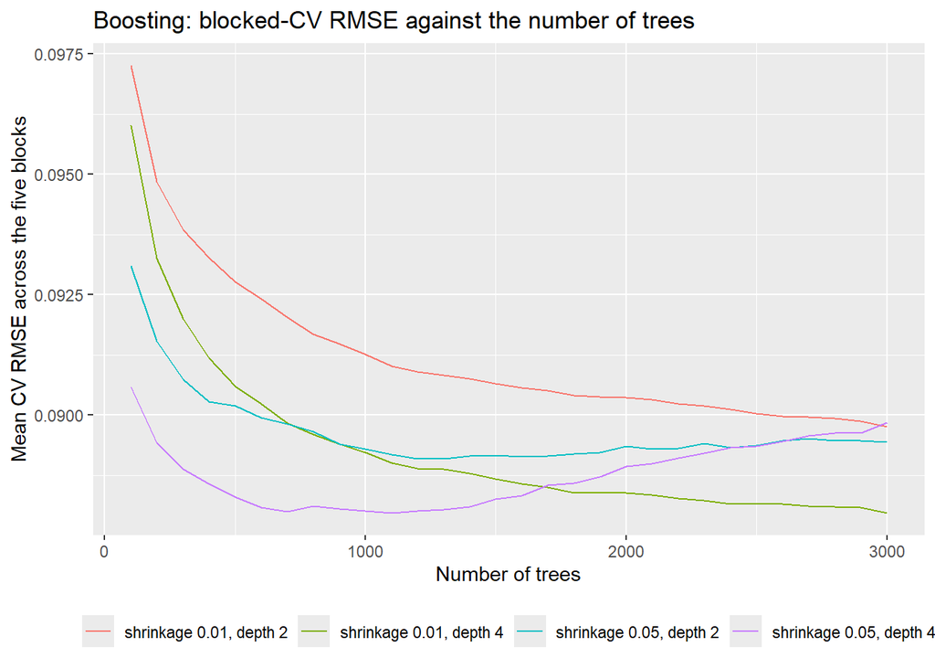

```r
gbm_cv %>%
  dplyr::select(shrinkage, depth, curve) %>%
  unnest(curve) %>%
  mutate(setting = paste0("shrinkage ", shrinkage, ", depth ", depth)) %>%
  ggplot(aes(x = n_trees, y = cv_RMSE, colour = setting)) +
  geom_line() +
  labs(title = "Boosting: blocked-CV RMSE against the number of trees",
       x = "Number of trees", y = "Mean CV RMSE across the five blocks", colour = NULL) +
  theme(legend.position = "bottom")
```

```r
set.seed(462)
boost_tuned.fit <- gbm(rel_log_cost_m2 ~ ., data = train_tree,
                       distribution = "gaussian", n.trees = gbm_best$n_trees,
                       interaction.depth = gbm_best$depth, shrinkage = gbm_best$shrinkage,
                       verbose = FALSE)

m_boost_tuned <- test_metrics(predict(boost_tuned.fit, newdata = test_tree,
                                      n.trees = gbm_best$n_trees, type = "response"),
                              test_tree$rel_log_cost_m2)
results <- add_result(results, paste0("Boosting (tuned: ", gbm_best$n_trees, " trees, depth ",
                                      gbm_best$depth, ", shrinkage ", gbm_best$shrinkage, ")"),
                      "drivers + region", metrics = m_boost_tuned)
paste("Test MSE: untuned boosting", round(m_boost[["test_MSE"]], 5),
      " tuned boosting", round(m_boost_tuned[["test_MSE"]], 5))
```

```
## [1] "Test MSE: untuned boosting 0.01224  tuned boosting 0.01138"
```

The curves say two things at once: where each setting bottoms out (the number of trees to use) and how flat the bottom is (how much it matters to get that number right). A curve that is still falling at 3,000 trees means the grid should be extended; one that turns up early is over-fitting and wants a smaller shrinkage.

### 5.4.3 Elastic net: `alpha` between ridge and lasso

`alpha` mixes the two penalties — 0 is ridge, 1 is lasso. Five values, each tuned for $\lambda$ on the same folds, compared at `lambda.min` (section 4.5 showed the one-SE rule is too blunt on these folds).

```r
alpha_grid <- c(0, 0.25, 0.5, 0.75, 1)

enet_cv <- map_dfr(alpha_grid, function(a) {
  fit <- cv.glmnet(x_train_reg, y_train, alpha = a, foldid = foldid)
  tibble(alpha = a,
         lambda_min = fit$lambda.min,
         cv_RMSE = sqrt(min(fit$cvm)),
         n_nonzero = sum(as.vector(coef(fit, s = "lambda.min"))[-1] != 0),
         fit = list(fit))
})

enet_cv %>%
  dplyr::select(-fit) %>%
  mutate(across(c(lambda_min, cv_RMSE), ~ round(.x, 5))) %>%
  knitr::kable(caption = "Elastic net (drivers + region): blocked-CV RMSE at lambda.min by alpha")
```

Elastic net (drivers + region): blocked-CV RMSE at lambda.min by alpha

| alpha | lambda_min | cv_RMSE | n_nonzero |
| --- | --- | --- | --- |
| 0.00 | 0.00368 | 0.09613 | 27 |
| 0.25 | 0.00012 | 0.09585 | 26 |
| 0.50 | 0.00008 | 0.09585 | 25 |
| 0.75 | 0.00108 | 0.09583 | 19 |
| 1.00 | 0.00107 | 0.09581 | 19 |

```r
enet_best <- enet_cv %>% arrange(cv_RMSE) %>% slice(1)
m_enet <- test_metrics(as.vector(predict(enet_best$fit[[1]], newx = x_test_reg, s = "lambda.min")), y_test)
results <- add_result(results, paste0("Elastic net (alpha = ", enet_best$alpha, ", lambda.min)"),
                      "drivers + region", metrics = m_enet)
cat("Chosen alpha:", enet_best$alpha, " test MSE:", round(m_enet[["test_MSE"]], 5), "\n")
```

```
## Chosen alpha: 1  test MSE: 0.01356
```

The expected shape here is a flat line: section 4.5 found ridge and lasso within 0.0001 of each other at `lambda.min`, so the mixtures between them should be too. If so, the honest sentence for the poster is that on this data the choice of penalty is cosmetic and the choice of features is not.

**Why the relative response matters most for the trees.** Every tree model here predicts a leaf mean learnt from 1996–2019 rows. Asked about 2024, a forest fitted on log *real* $/m² can only return costs it saw before 2020, and under-predicts every test year by the whole post-2019 rise. On the relative response there is no trend to miss: a district 20% dearer than the rest of the country in 2019 is predicted 20% dearer in 2024, which is the right kind of guess. Section 6.7 shows the size of the gap on the real response.

*A dozen models, one test set. Which is best, and does the answer depend on the model?*

# 6 Evaluate performance

## 6.1 Sensitivity: the two early-years drivers

The headline frame starts in 1996 because `dwell_per_1000` and `houses_yoy` do not exist before then. One row to show what that cost: the multiple linear regression without those two drivers, fitted on all 7,051 training rows from 1990Q2 and tested on all 1,611 test rows.

```r
drivers_9 <- setdiff(drivers, c("dwell_per_1000", "houses_yoy"))

train_9 <- df_train %>% dplyr::select(rel_log_cost_m2, all_of(drivers_9))
test_9  <- df_test  %>% dplyr::select(rel_log_cost_m2, all_of(drivers_9))
mlr_9.fit <- lm(rel_log_cost_m2 ~ ., data = train_9)

# same drivers on the headline frame, so the only difference is the rows
mlr_9c.fit <- lm(rel_log_cost_m2 ~ ., data = train_drv %>% dplyr::select(rel_log_cost_m2, all_of(drivers_9)))

m_9  <- test_metrics(predict(mlr_9.fit,  test_9),  test_9$rel_log_cost_m2)
m_9c <- test_metrics(predict(mlr_9c.fit, test_drv), test_drv$rel_log_cost_m2)

results <- add_result(results, "MLR, 9 drivers, all rows 1990+", "sensitivity",
                      summary(mlr_9.fit)$r.squared, summary(mlr_9.fit)$adj.r.squared, m_9)
results <- add_result(results, "MLR, 9 drivers, headline rows",  "sensitivity",
                      summary(mlr_9c.fit)$r.squared, summary(mlr_9c.fit)$adj.r.squared, m_9c)

cat(sprintf("Rows: %d (1990+) vs %d (1996+)\n", nrow(train_9), nrow(train_drv)))
```

```
## Rows: 7051 (1990+) vs 5696 (1996+)
```

```r
cat(sprintf("Test MSE, 9 drivers: %.5f on 1990+ rows, %.5f on 1996+ rows; 11 drivers on 1996+: %.5f\n",
            m_9[["test_MSE"]], m_9c[["test_MSE"]], m_mlr[["test_MSE"]]))
```

```
## Test MSE, 9 drivers: 0.01546 on 1990+ rows, 0.01604 on 1996+ rows; 11 drivers on 1996+: 0.01459
```

Two comparisons fall out. The second row against the first says what the 1990–95 rows add when the drivers are held fixed; the second row against the headline MLR says what the two dropped drivers add when the rows are held fixed. If the second gap is the larger, keeping the drivers was the right trade.

## 6.2 Goodness-of-fit (training data)

$$R^2 = \frac{TSS - RSS}{TSS}, \qquad
\bar R^2 = 1 - \frac{RSS / (n - p - 1)}{TSS / (n - 1)}$$

```r
results %>%
  dplyr::filter(!is.na(train_R2)) %>%
  dplyr::select(model, set, train_R2, adj_R2) %>%
  mutate(across(where(is.numeric), ~ round(.x, 4))) %>%
  knitr::kable(caption = "Training R2 and adjusted R2 for the least-squares models")
```

Training R2 and adjusted R2 for the least-squares models

| model | set | train_R2 | adj_R2 |
| --- | --- | --- | --- |
| Simple linear regression | one driver | 0.1212 | 0.1211 |
| Multiple linear regression | drivers | 0.1952 | 0.1936 |
| Multiple linear regression | drivers + district | 0.4090 | 0.4009 |
| Forward selection (3 drivers) | drivers | 0.1793 | 0.1788 |
| MLR, 9 drivers, all rows 1990+ | sensitivity | 0.1385 | 0.1374 |
| MLR, 9 drivers, headline rows | sensitivity | 0.1439 | 0.1426 |

```r
cat("For reference, the out-of-bag % variance explained: bagging",
    round(tail(bag.tree$rsq, 1) * 100, 1), " random forest", round(tail(rf.tree$rsq, 1) * 100, 1), "\n")
```

```
## For reference, the out-of-bag % variance explained: bagging 45  random forest 45
```

The district-fixed-effects model is the ceiling: no model of measured drivers should be expected to beat it on the training data, and the distance between it and the best drivers-only model is the share of the between-district difference that the drivers do not explain.

## 6.3 Test MSE and RMSE (2020Q1–2026Q2)

```r
results_test <- results %>%
  arrange(test_RMSE) %>%
  mutate(rank = row_number()) %>%
  dplyr::select(rank, model, set, test_MSE, test_RMSE, test_R2)

results_test %>%
  mutate(across(where(is.numeric), ~ round(.x, 5))) %>%
  knitr::kable(caption = "Every model on the same 1,611 test district-quarters, best first")
```

Every model on the same 1,611 test district-quarters, best first

| rank | model | set | test_MSE | test_RMSE | test_R2 |
| --- | --- | --- | --- | --- | --- |
| 1 | Bagging (mtry = 12) | drivers + region | 0.01134 | 0.10649 | 0.38868 |
| 2 | Boosting (tuned: 1100 trees, depth 4, shrinkage 0.05) | drivers + region | 0.01138 | 0.10669 | 0.38640 |
| 3 | Random forest (mtry = 4) | drivers + region | 0.01140 | 0.10679 | 0.38520 |
| 4 | Random forest (tuned: mtry = 4, nodesize = 5) | drivers + region | 0.01140 | 0.10679 | 0.38520 |
| 5 | Multiple linear regression | drivers + district | 0.01179 | 0.10858 | 0.36440 |
| 6 | Boosting (1000 trees, depth 2) | drivers + region | 0.01224 | 0.11062 | 0.34032 |
| 7 | Lasso (lambda.min) | drivers + region | 0.01356 | 0.11646 | 0.26887 |
| 8 | Elastic net (alpha = 1, lambda.min) | drivers + region | 0.01356 | 0.11646 | 0.26887 |
| 9 | Ridge (lambda.min) | drivers + region | 0.01357 | 0.11648 | 0.26854 |
| 10 | Regression tree (full) | drivers + region | 0.01413 | 0.11887 | 0.23828 |
| 11 | Regression tree (pruned, 11 leaves) | drivers + region | 0.01413 | 0.11887 | 0.23828 |
| 12 | Lasso (lambda.min) | drivers | 0.01458 | 0.12073 | 0.21418 |
| 13 | Multiple linear regression | drivers | 0.01459 | 0.12079 | 0.21339 |
| 14 | Ridge (lambda.min) | drivers | 0.01468 | 0.12117 | 0.20844 |
| 15 | Forward selection (3 drivers) | drivers | 0.01506 | 0.12272 | 0.18804 |
| 16 | Ridge (lambda.1se) | drivers + region | 0.01507 | 0.12277 | 0.18744 |
| 17 | MLR, 9 drivers, all rows 1990+ | sensitivity | 0.01546 | 0.12435 | 0.16636 |
| 18 | Lasso (lambda.1se) | drivers + region | 0.01589 | 0.12605 | 0.14346 |
| 19 | MLR, 9 drivers, headline rows | sensitivity | 0.01604 | 0.12665 | 0.13532 |
| 20 | Ridge (lambda.1se) | drivers | 0.01618 | 0.12720 | 0.12775 |
| 21 | Simple linear regression | one driver | 0.01637 | 0.12796 | 0.11724 |
| 22 | Lasso (lambda.1se) | drivers | 0.01669 | 0.12917 | 0.10050 |

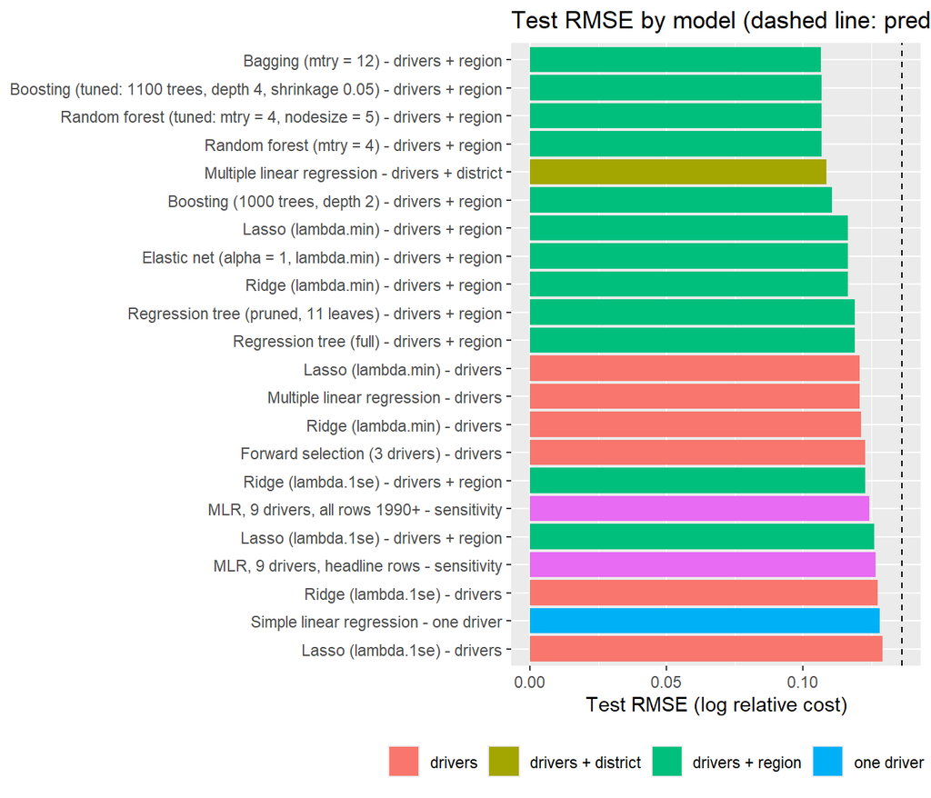

```r
results_test %>%
  mutate(model = fct_reorder(paste(model, "-", set), -test_RMSE)) %>%
  ggplot(aes(x = model, y = test_RMSE, fill = set)) +
  geom_col() +
  coord_flip() +
  geom_hline(yintercept = sqrt(mean((y_test - y_train_mean)^2)), linetype = "dashed") +
  labs(title = "Test RMSE by model (dashed line: predict the training mean)",
       x = NULL, y = "Test RMSE (log relative cost)", fill = NULL) +
  theme(legend.position = "bottom")
```

A test RMSE of 0.10 on a log scale means a typical prediction is about 10% off the district’s actual cost relative to the rest of New Zealand. The dashed line is the no-model baseline. Read the table with two questions: which model is best, and how far apart are the models — if the spread among the sensible models is a few thousandths of RMSE, the choice of model matters much less than the choice of drivers, and the poster should say so.

## 6.4 Comparison with Niwesh’s build

Niwesh’s `03_rq1_models.Rmd` fitted the same response on the same quarters (his frame is ours minus Chatham Islands and Kawerau, two training rows) with different packages (`glmnet` with his own tuning loop, `ranger`, `rpart`). His test results are in `t09_test_results.csv`; where the two builds share a model, the test RMSE should agree to the third decimal. Where they do not, the reason is a difference in method and should be nameable.

```r
niwesh_file <- file.path(data_root, "t09_test_results.csv")

if (file.exists(niwesh_file)) {
  niwesh <- read_csv(niwesh_file, show_col_types = FALSE) %>%
    dplyr::select(niwesh_model = model, niwesh_set = set, niwesh_test_RMSE = test_rmse, niwesh_test_R2 = test_r2)

  # the pairs of models that are the same thing in both builds
  model_pairs <- tribble(
    ~model,                               ~set,                 ~niwesh_model,       ~niwesh_set,
    "Multiple linear regression",         "drivers",            "Linear regression", "drivers",
    "Multiple linear regression",         "drivers + district", "Linear regression", "district",
    "Ridge (lambda.1se)",                 "drivers",            "Ridge",             "drivers",
    "Lasso (lambda.1se)",                 "drivers",            "Lasso",             "drivers",
    "Random forest (mtry = 4)",           "drivers + region",   "Random forest",     "drivers")

  comparison <- model_pairs %>%
    inner_join(results, by = c("model", "set")) %>%
    inner_join(niwesh, by = c("niwesh_model", "niwesh_set")) %>%
    mutate(diff_RMSE = test_RMSE - niwesh_test_RMSE) %>%
    dplyr::select(model, set, test_RMSE, niwesh_model, niwesh_set, niwesh_test_RMSE, diff_RMSE, test_R2, niwesh_test_R2)

  comparison %>%
    mutate(across(where(is.numeric), ~ round(.x, 4))) %>%
    knitr::kable(caption = "Our test RMSE vs Niwesh's for the models both builds fitted")
} else {
  cat("t09_test_results.csv not found in", data_root, "- comparison skipped.\n")
}
```

Our test RMSE vs Niwesh’s for the models both builds fitted

| model | set | test_RMSE | niwesh_model | niwesh_set | niwesh_test_RMSE | diff_RMSE | test_R2 | niwesh_test_R2 |
| --- | --- | --- | --- | --- | --- | --- | --- | --- |
| Multiple linear regression | drivers | 0.1208 | Linear regression | drivers | 0.1162 | 0.0045 | 0.2134 | 0.2358 |
| Multiple linear regression | drivers + district | 0.1086 | Linear regression | district | 0.1066 | 0.0020 | 0.3644 | 0.3577 |
| Ridge (lambda.1se) | drivers | 0.1272 | Ridge | drivers | 0.1164 | 0.0108 | 0.1278 | 0.2343 |
| Lasso (lambda.1se) | drivers | 0.1292 | Lasso | drivers | 0.1168 | 0.0123 | 0.1005 | 0.2279 |
| Random forest (mtry = 4) | drivers + region | 0.1068 | Random forest | drivers | 0.1134 | -0.0066 | 0.3852 | 0.2729 |

The two linear regressions are the same estimator on the same drivers, so their gap (0.0045 RMSE on the drivers set, 0.0020 with district) is larger than it should be. Two rows differ in training, but three differ in the test set — Chatham Islands and Kawerau have one and two test rows — and a tiny district can carry a very large error. Our MLR scored on exactly his 1,608 test rows:

```r
his_test_rows <- !df_test_c$ta %in% c("Chatham Islands Territory", "Kawerau District")

cat(sprintf("MLR, drivers:            RMSE %.4f on all %d test rows, %.4f on Niwesh's %d\n",
            sqrt(mean((test_drv$rel_log_cost_m2 - pred_mlr)^2)), nrow(test_drv),
            sqrt(mean((test_drv$rel_log_cost_m2[his_test_rows] - pred_mlr[his_test_rows])^2)), sum(his_test_rows)))
```

```
## MLR, drivers:            RMSE 0.1208 on all 1611 test rows, 0.1202 on Niwesh's 1608
```

```r
cat(sprintf("MLR, drivers + district: RMSE %.4f on all %d test rows, %.4f on Niwesh's %d\n",
            sqrt(mean((test_ta$rel_log_cost_m2 - pred_mlr_ta)^2)), nrow(test_ta),
            sqrt(mean((test_ta$rel_log_cost_m2[his_test_rows] - pred_mlr_ta[his_test_rows])^2)), sum(his_test_rows)))
```

```
## MLR, drivers + district: RMSE 0.1086 on all 1611 test rows, 0.1084 on Niwesh's 1608
```

```r
# the three rows themselves
df_test_c %>%
  dplyr::filter(!his_test_rows) %>%
  mutate(predicted = pred_mlr[!his_test_rows], error = rel_log_cost_m2 - predicted) %>%
  dplyr::select(ta, yq, houses_n, rel_log_cost_m2, predicted, error) %>%
  mutate(across(where(is.numeric), ~ round(.x, 3))) %>%
  knitr::kable(caption = "The three test rows Niwesh's build does not score")
```

The three test rows Niwesh’s build does not score

| ta | yq | houses_n | rel_log_cost_m2 | predicted | error |
| --- | --- | --- | --- | --- | --- |
| Chatham Islands Territory | 2020Q4 | 5 | 0.186 | -0.299 | 0.486 |
| Kawerau District | 2020Q3 | 7 | 0.041 | -0.104 | 0.144 |
| Kawerau District | 2021Q3 | 5 | -0.030 | -0.115 | 0.085 |

If the gap closes on his rows, the difference was those three rows and the two builds agree; if it does not, the remaining distance is in the data preparation and should be found before the poster quotes either number. The other pairings differ for known reasons. Ridge and lasso: his tuning chose $\lambda \approx 0.0004$, which is OLS in all but name, while our `lambda.1se` values are 300–3,000 times larger — compare his numbers with our `lambda.min` rows instead, which sit within 0.001 of OLS. Random forest: ours has `region` and his does not, and it is 0.0066 RMSE better for it — the same lesson as section 4.6, that geography is worth more than any tuning.

## 6.5 Which drivers matter — three rankings side by side

```r
rank_lasso <- coef_table %>%
  transmute(driver, lasso = abs(`Lasso (1se)`)) %>%
  mutate(lasso_rank = min_rank(-lasso))

rank_rf <- importance(rf.tree) %>%
  as.data.frame() %>%
  rownames_to_column("driver") %>%
  transmute(driver, rf = `%IncMSE`) %>%
  mutate(rf_rank = min_rank(-rf))

rank_boost <- summary(boost.fit, plotit = FALSE) %>%
  transmute(driver = as.character(var), boost = rel.inf) %>%
  mutate(boost_rank = min_rank(-boost))

rank_lasso %>%
  full_join(rank_rf, by = "driver") %>%
  full_join(rank_boost, by = "driver") %>%
  dplyr::filter(driver %in% drivers) %>%
  mutate(mean_rank = rowMeans(cbind(lasso_rank, rf_rank, boost_rank), na.rm = TRUE)) %>%
  arrange(mean_rank) %>%
  mutate(across(c(lasso, rf, boost, mean_rank), ~ round(.x, 3))) %>%
  knitr::kable(caption = "Driver rankings: lasso |coefficient| (1se), forest %IncMSE, boosting relative influence")
```

Driver rankings: lasso |coefficient| (1se), forest %IncMSE, boosting relative influence

| driver | lasso | lasso_rank | rf | rf_rank | boost | boost_rank | mean_rank |
| --- | --- | --- | --- | --- | --- | --- | --- |
| dwell_per_1000 | 0.008 | 2 | 70.317 | 2 | 12.307 | 3 | 2.333 |
| log_resid_alt_real | 0.021 | 1 | 61.070 | 4 | 23.669 | 2 | 2.333 |
| t_index | 0.000 | 3 | 63.835 | 3 | 7.769 | 4 | 3.333 |
| avg_house_m2 | 0.000 | 3 | 29.513 | 8 | 6.261 | 5 | 5.333 |
| rel_house_m2 | 0.000 | 3 | 33.991 | 7 | 5.587 | 6 | 5.333 |
| log_houses_n | 0.000 | 3 | 39.020 | 5 | 3.706 | 8 | 5.333 |
| log_nonres_real | 0.000 | 3 | 36.918 | 6 | 4.347 | 7 | 5.333 |
| multiunit_share | 0.000 | 3 | 26.819 | 9 | 0.908 | 10 | 7.333 |
| houses_yoy | 0.000 | 3 | 11.225 | 12 | 3.243 | 9 | 8.000 |
| apt_share | 0.000 | 3 | 15.738 | 10 | 0.451 | 12 | 8.333 |
| retire_share | 0.000 | 3 | 13.652 | 11 | 0.754 | 11 | 8.333 |

This is the table that answers the “which parameters are important” half of RQ1. A driver ranked near the top by all three — a linear model with selection, a bagged ensemble with permutation importance, and a boosted ensemble — is important in a way that does not depend on the modelling choice. A driver that is high in one and low in the others is picking up something model-specific (the forest and boosting can use a driver through interactions that the lasso cannot see), and the text should say which.

## 6.6 Bootstrap standard errors for the headline coefficients

Module 5’s check on the standard errors `summary()` reports: refit the drivers-only linear model on 100 bootstrap samples of the training rows and take the standard deviation of each coefficient across refits. If the bootstrap SE is much larger than the formula SE, the formula’s assumptions (independent, equal-variance errors) are being strained — plausible here, since the 5,696 rows are 67 districts observed repeatedly.

```r
set.seed(462)
bootstrap_samples <- replicate(n = 100,
                               expr = train_drv[sample(1:nrow(train_drv), replace = TRUE), ],
                               simplify = FALSE)

boot_fits  <- lapply(bootstrap_samples, function(s) lm(rel_log_cost_m2 ~ ., data = s))
boot_coefs <- sapply(boot_fits, coef)      # one column per bootstrap fit

# the three drivers with the largest standardised OLS coefficients
top3 <- std_coef(mlr.fit, train_drv) %>%
  arrange(desc(abs(std_coefficient))) %>%
  slice(1:3) %>% pull(driver)

tibble(driver = top3,
       estimate     = coef(mlr.fit)[top3],
       formula_SE   = summary(mlr.fit)$coefficients[top3, "Std. Error"],
       bootstrap_SE = apply(boot_coefs[top3, , drop = FALSE], 1, sd),
       boot_CI_low  = apply(boot_coefs[top3, , drop = FALSE], 1, quantile, probs = 0.025),
       boot_CI_high = apply(boot_coefs[top3, , drop = FALSE], 1, quantile, probs = 0.975)) %>%
  mutate(ratio = bootstrap_SE / formula_SE,
         across(-driver, ~ round(.x, 4))) %>%
  knitr::kable(caption = "Formula vs bootstrap standard errors, 100 bootstrap refits")
```

Formula vs bootstrap standard errors, 100 bootstrap refits

| driver | estimate | formula_SE | bootstrap_SE | boot_CI_low | boot_CI_high | ratio |
| --- | --- | --- | --- | --- | --- | --- |
| log_resid_alt_real | 0.0578 | 0.0028 | 0.0031 | 0.0527 | 0.0639 | 1.0831 |
| log_houses_n | -0.0268 | 0.0028 | 0.0031 | -0.0331 | -0.0206 | 1.1032 |
| dwell_per_1000 | 0.0065 | 0.0003 | 0.0004 | 0.0058 | 0.0073 | 1.1317 |

```r
confint(mlr.fit)[top3, ]
```

```
##                           2.5 %       97.5 %
## log_resid_alt_real  0.052247706  0.063355094
## log_houses_n       -0.032288587 -0.021320421
## dwell_per_1000      0.005830436  0.007191324
```

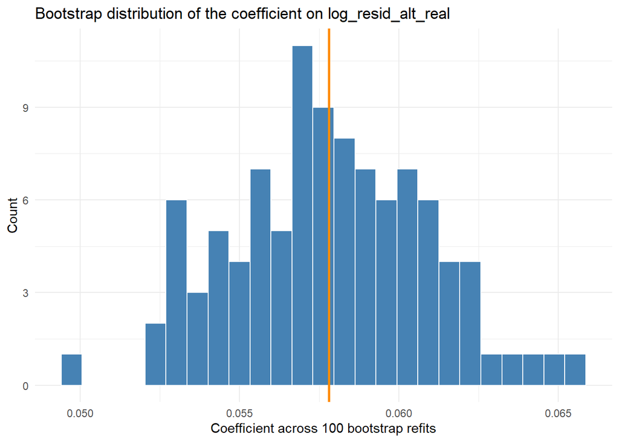

```r
ggplot(data.frame(b = boot_coefs[top3[1], ]), aes(x = b)) +
  geom_histogram(bins = 25, fill = "steelblue", colour = "white") +
  geom_vline(xintercept = coef(mlr.fit)[top3[1]], colour = "darkorange", linewidth = 1) +
  labs(title = paste("Bootstrap distribution of the coefficient on", top3[1]),
       x = "Coefficient across 100 bootstrap refits", y = "Count") +
  theme_minimal()
```

A ratio near 1 says the formula SEs can be trusted; a ratio well above 1 says the real uncertainty is larger and the confidence intervals in section 3 should be read as optimistic. Note what the bootstrap does *not* fix: rows from the same district are resampled independently, so district-level clustering is still ignored. A block bootstrap by district would be the stricter check, and is outside this document’s scope.

## 6.7 The real response and the extrapolation problem

Finally, the response as the pitch worded it: log real $/m² itself. Two models, the ones at the two extremes of the extrapolation question — the drivers-plus-district linear model, which carries a straight-line trend in `t_index`, and the random forest, which cannot extrapolate at all.

```r
train_real    <- df_train_c %>% dplyr::select(log_real_cost_m2, all_of(drivers), ta)
test_real     <- df_test_c  %>% dplyr::select(log_real_cost_m2, all_of(drivers), ta)
train_real_rf <- as.data.frame(df_train_c %>% dplyr::select(log_real_cost_m2, all_of(drivers), region))
test_real_rf  <- as.data.frame(df_test_c  %>% dplyr::select(log_real_cost_m2, all_of(drivers), region))

mlr_real.fit <- lm(log_real_cost_m2 ~ ., data = train_real)
set.seed(462)
rf_real.tree <- randomForest(log_real_cost_m2 ~ ., data = train_real_rf, mtry = 4, ntree = 500)

pred_real_lm <- predict(mlr_real.fit, newdata = test_real)
pred_real_rf <- predict(rf_real.tree, newdata = test_real_rf)

real_metrics <- function(pred, actual) {
  c(test_RMSE = sqrt(mean((actual - pred)^2)),
    test_R2   = 1 - sum((actual - pred)^2) / sum((actual - mean(train_real$log_real_cost_m2))^2),
    mean_bias = mean(pred - actual))
}

rbind(`MLR, drivers + district` = real_metrics(pred_real_lm, test_real$log_real_cost_m2),
      `Random forest, drivers + region` = real_metrics(pred_real_rf, test_real$log_real_cost_m2)) %>%
  round(4) %>%
  knitr::kable(caption = "Log real $/m2 as the response: test RMSE, R2 and mean bias (negative = under-prediction)")
```

Log real $/m2 as the response: test RMSE, R2 and mean bias (negative = under-prediction)

|  | test_RMSE | test_R2 | mean_bias |
| --- | --- | --- | --- |
| MLR, drivers + district | 0.1035 | 0.7513 | 0.0113 |
| Random forest, drivers + region | 0.1133 | 0.7019 | -0.0423 |

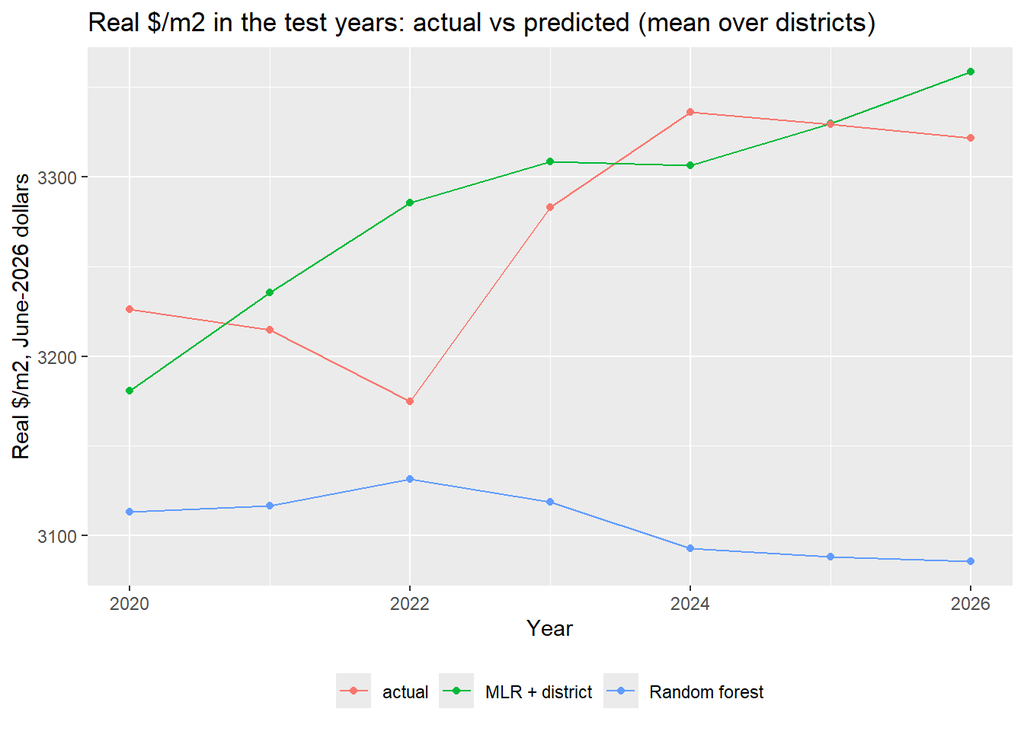

```r
df_test_c %>%
  mutate(`MLR + district` = pred_real_lm, `Random forest` = pred_real_rf) %>%
  dplyr::select(year, actual = log_real_cost_m2, `MLR + district`, `Random forest`) %>%
  pivot_longer(-year, names_to = "series", values_to = "value") %>%
  group_by(year, series) %>%
  summarise(mean_real = mean(exp(value)), .groups = "drop") %>%
  ggplot(aes(x = year, y = mean_real, colour = series)) +
  geom_line() + geom_point() +
  labs(title = "Real $/m2 in the test years: actual vs predicted (mean over districts)",
       x = "Year", y = "Real $/m2, June-2026 dollars", colour = NULL) +
  theme(legend.position = "bottom")
```

Two things in this figure are easy to misread. First, in June-2026 dollars the test years are nearly flat — the national mean sits between about $3,180 and $3,340 per m² across 2020–2026, dipping in 2022 and rising through 2024. The 2021–23 cost spike that everyone remembers is a *nominal* spike, and the CGPI deflator has taken most of it out; what is left is the few percent by which house prices outran the construction price index. Second, the $R^2$ values (0.75 and 0.70) are far higher than anything in the relative-cost tables, not because the models are better but because the between-district differences are back in the response and both models carry location.

Within that, the extrapolation problem shows as predicted, at a smaller scale: the forest sits about 4% low across the whole test period (mean bias −0.042) and drifts lower after 2022, because its `t_index` leaves end at 2019 and nothing in the drivers tells it that real costs kept rising; the linear model’s straight trend tracks the level well (bias +0.011) but overshoots by 2026. Neither is a safe way to forecast real dollars. The relative model is the one to trust across districts, and real $/m² is best answered as “the national series times the district’s relative position”, which is how the poster should put it.

## 6.8 Where this leaves RQ1

The three parts of the answer, each pointing at the table or figure that supports it:

Location first. Adding the district to the linear model lifts adjusted $R^2$ from 0.19 to 0.40 (section 3.4), and the same districts sit at the top and bottom of the ranking for thirty years (section 2.2) — Queenstown-Lakes 16% above the rest of the country at the median, Wellington City 11%, Ōpōtiki 17% below. Whatever makes them so is mostly not in this dataset — land, remoteness, the kind of houses being built. The three regional dummies the lasso keeps (section 4.6: Wellington and Hawke’s Bay dear, Manawatū-Whanganui cheap) are the compact list of where that unexplained premium sits after the drivers have had their say.

*End of document (stages 1–6; section 7, extensions, to follow)*